# Relative cover analysis

Claudia Campanini

Load some basic libraries

```r
library(dplyr)
```

```r
library(ggplot2)
library(readxl)   # to import excel datasets
library(writexl) # to export df to excel files (write_xlsx)
library(here)
```

# 1 MEAN RELATIVE BENTHIC COVER BY CATEGORY

Load input file

```r
cov_df <- read_excel(here("Multi-taxa_data","PLITs","3-Clean_data","plits_ext_df.xlsx"))
str(cov_df)
```

```
## tibble [621 × 10] (S3: tbl_df/tbl/data.frame)
##  $ Category  : chr [1:621] "algae" "boulder" "hard_coral" "other" ...
##  $ Abs_cov   : num [1:621] 2230 48 0 0 156 122 60 7 0 2390 ...
##  $ Rel_cov   : num [1:621] 0.85 0.018 0 0 0.059 0.047 0.023 0.003 0 0.92 ...
##  $ Depth_rep : chr [1:621] "D1" "D1" "D1" "D1" ...
##  $ Site      : chr [1:621] "AW" "AW" "AW" "AW" ...
##  $ depth     : chr [1:621] "Deep" "Deep" "Deep" "Deep" ...
##  $ Transect  : chr [1:621] "AW_D1" "AW_D1" "AW_D1" "AW_D1" ...
##  $ Site_depth: chr [1:621] "AW_Deep" "AW_Deep" "AW_Deep" "AW_Deep" ...
##  $ Replicate : num [1:621] 1 1 1 1 1 1 1 1 1 2 ...
##  $ sd_rel_cov: num [1:621] 0.05 0.01 0.01 0 0.03 0.02 0.01 0.01 0 0.05 ...
```

## 1.1 PER SITE

Follow the link for explanation of dcast function https://seananderson.ca/2013/10/19/reshape/

```r
mean_rel_cov_site <- cov_df %>%
  group_by(Site, Category) %>%
  summarise(Mean_rel_cov=round(mean(Rel_cov),2))
library(reshape2) #needed for dcast function
mean_rel_cov_site <- dcast(mean_rel_cov_site, Site ~ Category)
mean_rel_cov_site <- mean_rel_cov_site %>%
  mutate(Pressure = case_when(Site == 'HI' |
                              Site == "S1" |
                              Site == "S2" ~ "Low",
                              Site == "ZP" |
                              Site == 'ZA' |
                              Site == "YO" |
                              Site == "MI" ~ "Medium",
                              Site == 'SK' |
                              Site == 'SN' |
                              Site == "AW" |
                              Site == "G1" |
                              Site == "G2"~ "High"))

mean_rel_cov_site[,1]<-factor(mean_rel_cov_site[,1],levels=c("HI", "S1", "S2", "ZP", "ZA", "YO", "MI","SK", "SN", "AW", "G1", "G2"))

mean_rel_cov_site <- mean_rel_cov_site[,c(1,11,2:10)] #re-ordering columns
mean_rel_cov_site
```

```
##    Site Pressure algae boulder hard_coral other rubble sand soft_coral unknown
## 1    AW     High  0.90    0.01       0.04  0.00   0.02 0.02       0.00    0.01
## 2    G1     High  0.67    0.00       0.16  0.00   0.00 0.02       0.09    0.02
## 3    G2     High  0.28    0.00       0.07  0.00   0.00 0.00       0.60    0.00
## 4    HI      Low  0.38    0.01       0.55  0.00   0.00 0.00       0.02    0.02
## 5    MI   Medium  0.51    0.00       0.16  0.00   0.00 0.00       0.27    0.01
## 6    S1      Low  0.59    0.00       0.33  0.00   0.02 0.05       0.00    0.01
## 7    S2      Low  0.48    0.00       0.30  0.02   0.13 0.07       0.00    0.00
## 8    SK     High  0.79    0.00       0.17  0.00   0.00 0.01       0.00    0.03
## 9    SN     High  0.52    0.10       0.06  0.00   0.00 0.04       0.24    0.03
## 10   YO   Medium  0.54    0.01       0.34  0.00   0.00 0.02       0.04    0.03
## 11   ZA   Medium  0.70    0.04       0.20  0.00   0.00 0.01       0.02    0.02
## 12   ZP   Medium  0.71    0.00       0.26  0.00   0.00 0.00       0.01    0.01
##    zoanthids
## 1       0.00
## 2       0.04
## 3       0.04
## 4       0.00
## 5       0.04
## 6       0.00
## 7       0.00
## 8       0.00
## 9       0.01
## 10      0.02
## 11      0.01
## 12      0.00
```

```r
write_xlsx(mean_rel_cov_site, here("Multi-taxa_data","PLITs","3-Clean_data","mean_rel_cov_site.xlsx"))
```

## 1.2 PER SITE WITHIN Depth

```r
mean_rel_cov_df <- cov_df %>%
  group_by(Site_depth, Category) %>%
  summarise(Mean_rel_cov=round(mean(Rel_cov),2))
Site_depth <- mean_rel_cov_df$Site_depth

library(tidyr) # needed for separate_wider_delim function
mean_rel_cov_df <- mean_rel_cov_df %>%
  separate_wider_delim(Site_depth, "_", names = c("Site", "Depth")) %>%
  mutate(Site_depth=Site_depth)

rm(Site_depth)

mean_rel_cov_df <- mean_rel_cov_df %>%
  mutate(Pressure = case_when(Site == "HI" |
                              Site == "S1" |
                              Site == "S2" ~ "Low",
                              Site == "ZP" |
                              Site == 'ZA' |
                              Site == "YO" |
                              Site == "MI" ~ "Medium",
                              Site == 'SK' |
                              Site == 'SN' |
                              Site == "AW" |
                              Site == "G1" |
                              Site == "G2"~ "High"))

mean_rel_cov_df$Site_depth <- as.factor(mean_rel_cov_df$Site_depth)
mean_rel_cov_df$Pressure <- ordered(mean_rel_cov_df$Pressure,levels=c("Low","Medium","High"))

mean_rel_cov_wide <- dcast(mean_rel_cov_df, Site_depth + Pressure ~ Category, value.var = "Mean_rel_cov")
mean_rel_cov_wide
```

```
##    Site_depth Pressure algae boulder hard_coral other rubble sand soft_coral
## 1     AW_Deep     High  0.90    0.01       0.01  0.00   0.03 0.03       0.01
## 2  AW_Shallow     High  0.91    0.01       0.06  0.00   0.01 0.01       0.00
## 3     G1_Deep     High  0.64    0.00       0.13  0.00   0.01 0.05       0.15
## 4  G1_Shallow     High  0.69    0.00       0.18  0.00   0.00 0.00       0.02
## 5     G2_Deep     High  0.42    0.00       0.14  0.00   0.00 0.00       0.35
## 6  G2_Shallow     High  0.14    0.00       0.00  0.00   0.00 0.00       0.86
## 7     HI_Deep      Low  0.35    0.01       0.58  0.00   0.00 0.01       0.02
## 8  HI_Shallow      Low  0.42    0.01       0.53  0.00   0.00 0.00       0.02
## 9     MI_Deep   Medium  0.32    0.00       0.20  0.00   0.00 0.00       0.42
## 10 MI_Shallow   Medium  0.71    0.01       0.12  0.00   0.00 0.00       0.13
## 11    S1_Deep      Low  0.57    0.00       0.35  0.00   0.03 0.05       0.00
## 12 S1_Shallow      Low  0.61    0.00       0.30  0.00   0.01 0.06       0.01
## 13    S2_Deep      Low  0.45    0.00       0.34  0.03   0.12 0.06       0.00
## 14 S2_Shallow      Low  0.51    0.01       0.26  0.00   0.14 0.07       0.00
```

[output cut: 33 more lines]

```r
write_xlsx(mean_rel_cov_site, here("Multi-taxa_data","PLITs","3-Clean_data","mean_rel_cov_Site_depth.xlsx"))
```

## 1.3 STACKED BARPLOTS

Load the color-blind-friendly palette with black:

```r
relcovPalette <- c("#009E73","#E69F00","#D55E00", "#56B4E9", "#F0E442", "#0072B2", "#CC79A7","#000000","#999999") #I changed the order compared to the original version
```

Stacked barplot of the mean relative benthic cover

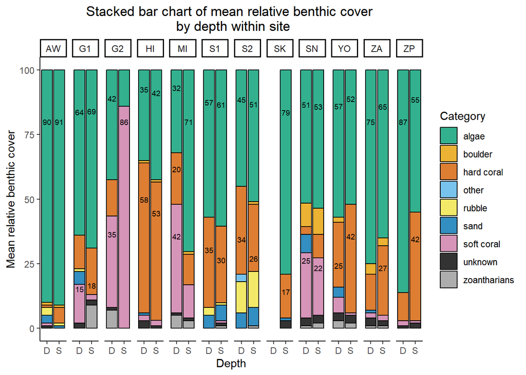

```r
mean_rel_cov_df <- mean_rel_cov_df %>%                               # Replacing values
  mutate(Depth = replace(Depth, Depth == "Deep", "D")) %>%                     # Replacing values
  mutate(Depth = replace(Depth, Depth == "Shallow", "S"))

ggplot(mean_rel_cov_df, aes(fill=Category, y=Mean_rel_cov, x=Depth, label=Mean_rel_cov)) +
  geom_bar(position="fill", stat="identity",alpha=.8, color = "black")+
  facet_grid(~ Site)+
  theme_classic()+
  labs(x="Depth",
       y="Mean relative benthic cover",
       title= "Stacked bar chart of mean relative benthic cover \n by depth within site")+
  geom_text(aes(Depth, Mean_rel_cov, label = Mean_rel_cov*100),
            data = subset(mean_rel_cov_df,mean_rel_cov_df$Mean_rel_cov>= .15),
            size = 2.5, position = position_fill(vjust = 0.8),color="black")+
  theme(plot.title = element_text(hjust = 0.5))+
  scale_fill_manual(labels = c("algae",
                                "boulder",
                                "hard coral",
                                "other",
                                "rubble",
                                "sand",
                                "soft coral",
                                "unknown",
                                "zoantharians"), values=relcovPalette)+
  scale_y_continuous(limits = c(0, 1),
                     breaks = c(0, 0.25, 0.50, 0.75,1),
                     labels = c(0, 25, 50, 75,100))
```

```r
ggsave("relcov_stacked.tiff",
       units ="in", width = 5, height = 4, dpi = 300, compression = 'lzw',
       path = here("Multi-taxa_data","PLITs","4-Visualization_outputs"))
```

# 2 nMDS

Load packages

```r
#VEGAN----
library(vegan)#load package
#install.packages("htmltools")
library(htmltools)
library(MASS)
library(dplyr)
library(readxl)   # to import excel datasets
```

## 2.1 Format the data

Load relative benthic cover data

```r
#Relative benthic cover dataframe

cov_df <- read_excel(here("Multi-taxa_data","PLITs","3-Clean_data","Rel_cov_input.xlsx"))
str(cov_df)
```

```
## tibble [69 × 24] (S3: tbl_df/tbl/data.frame)
##  $ Transect  : chr [1:69] "AW_D1" "AW_D2" "AW_D3" "AW_S1" ...
##  $ Site      : chr [1:69] "AW" "AW" "AW" "AW" ...
##  $ Depth_rep : chr [1:69] "D1" "D2" "D3" "S1" ...
##  $ depth     : chr [1:69] "Deep" "Deep" "Deep" "Shallow" ...
##  $ Site_depth: chr [1:69] "AW_Deep" "AW_Deep" "AW_Deep" "AW_Shallow" ...
##  $ Replicate : chr [1:69] "1" "2" "3" "1" ...
##  $ algae     : num [1:69] 0.85 0.92 0.934 0.953 0.874 0.899 0.497 0.691 0.734 0.8 ...
##  $ boulder   : num [1:69] 0.018 0 0.01 0 0.023 0 0 0 0 0 ...
##  $ hard_coral: num [1:69] 0 0.018 0.026 0.023 0.073 0.075 0.104 0.143 0.152 0.167 ...
##  $ other     : num [1:69] 0 0.001 0 0 0 0 0 0 0 0 ...
##  $ rubble    : num [1:69] 0.059 0.004 0.014 0.019 0.001 0.01 0.005 0.012 0 0 ...
##  $ sand      : num [1:69] 0.047 0.042 0.006 0.003 0.024 0.008 0.096 0.036 0.014 0 ...
##  $ soft_coral: num [1:69] 0.023 0.001 0 0 0.001 0.002 0.276 0.107 0.077 0 ...
##  $ unknown   : num [1:69] 0.003 0.014 0.009 0.001 0.004 0.003 0.023 0.01 0.024 0.033 ...
##  $ zoanthids : num [1:69] 0 0 0 0 0 0.003 0 0 0 0 ...
##  $ sd_alg    : num [1:69] 0.05 0.05 0.05 0.04 0.04 0.04 0.13 0.13 0.13 0.1 ...
##  $ sd_boulder: num [1:69] 0.01 0.01 0.01 0.01 0.01 0.01 0 0 0 0 ...
##  $ sd_hc     : num [1:69] 0.01 0.01 0.01 0.03 0.03 0.03 0.03 0.03 0.03 0.08 ...
##  $ sd_other  : num [1:69] 0 0 0 0 0 0 0 0 0 0 ...
##  $ sd_rubble : num [1:69] 0.03 0.03 0.03 0.01 0.01 0.01 0.01 0.01 0.01 0 ...
##  $ sd_sand   : num [1:69] 0.02 0.02 0.02 0.01 0.01 0.01 0.04 0.04 0.04 0 ...
##  $ sd_softc  : num [1:69] 0.01 0.01 0.01 0 0 0 0.11 0.11 0.11 0.03 ...
##  $ sd_unknown: num [1:69] 0.01 0.01 0.01 0 0 0 0.01 0.01 0.01 0.01 ...
##  $ sd_zoanth : num [1:69] 0 0 0 0 0 0 0 0 0 0.12 ...
```

```r
cov_df <- cov_df %>%
  rename(Depth = depth)

cov_df <- cov_df %>%
  mutate(Pressure = case_when(Site == 'HI' |
                              Site == "S1" |
                              Site == "S2" ~ "Low",
                              Site == "ZP" |
                              Site == 'ZA' |
                              Site == "YO" |
                              Site == "MI" ~ "Medium",
                              Site == 'SK' |
                              Site == 'SN' |
                              Site == "AW" |
                              Site == "G1" |
                              Site == "G2"~ "High"))

cov_df <- cov_df[ ,c(1:6, 25, 7:24)]

cov_df$Site<-ordered(cov_df$Site,levels=c("HI", "S1", "S2", "ZP", "ZA", "YO", "MI","SK", "SN", "AW", "G1", "G2"))

cov_df$Pressure<-ordered(cov_df$Pressure,levels=c("Low", "Medium", "High"))

cov_df[,c(1,3:6)] <- lapply(cov_df[,c(1,3:6)], as.factor)  ## as.factor() could also be used

cov_df[,8:25] <- lapply(cov_df[,8:25], as.numeric)

cov_df <- cov_df[,-c(17:25)]

str(cov_df)
```

```
## tibble [69 × 16] (S3: tbl_df/tbl/data.frame)
##  $ Transect  : Factor w/ 69 levels "AW_D1","AW_D2",..: 1 2 3 4 5 6 7 8 9 10 ...
##  $ Site      : Ord.factor w/ 12 levels "HI"<"S1"<"S2"<..: 10 10 10 10 10 10 11 11 11 11 ...
##  $ Depth_rep : Factor w/ 6 levels "D1","D2","D3",..: 1 2 3 4 5 6 1 2 3 4 ...
##  $ Depth     : Factor w/ 2 levels "Deep","Shallow": 1 1 1 2 2 2 1 1 1 2 ...
##  $ Site_depth: Factor w/ 23 levels "AW_Deep","AW_Shallow",..: 1 1 1 2 2 2 3 3 3 4 ...
##  $ Replicate : Factor w/ 3 levels "1","2","3": 1 2 3 1 2 3 1 2 3 1 ...
##  $ Pressure  : Ord.factor w/ 3 levels "Low"<"Medium"<..: 3 3 3 3 3 3 3 3 3 3 ...
##  $ algae     : num [1:69] 0.85 0.92 0.934 0.953 0.874 0.899 0.497 0.691 0.734 0.8 ...
##  $ boulder   : num [1:69] 0.018 0 0.01 0 0.023 0 0 0 0 0 ...
##  $ hard_coral: num [1:69] 0 0.018 0.026 0.023 0.073 0.075 0.104 0.143 0.152 0.167 ...
##  $ other     : num [1:69] 0 0.001 0 0 0 0 0 0 0 0 ...
##  $ rubble    : num [1:69] 0.059 0.004 0.014 0.019 0.001 0.01 0.005 0.012 0 0 ...
##  $ sand      : num [1:69] 0.047 0.042 0.006 0.003 0.024 0.008 0.096 0.036 0.014 0 ...
##  $ soft_coral: num [1:69] 0.023 0.001 0 0 0.001 0.002 0.276 0.107 0.077 0 ...
##  $ unknown   : num [1:69] 0.003 0.014 0.009 0.001 0.004 0.003 0.023 0.01 0.024 0.033 ...
##  $ zoanthids : num [1:69] 0 0 0 0 0 0.003 0 0 0 0 ...
```

```r
#create a df with the independent variables
ind_df <- as.data.frame(cov_df[,c(1:7)])
str(ind_df)
```

```
## 'data.frame':    69 obs. of  7 variables:
##  $ Transect  : Factor w/ 69 levels "AW_D1","AW_D2",..: 1 2 3 4 5 6 7 8 9 10 ...
##  $ Site      : Ord.factor w/ 12 levels "HI"<"S1"<"S2"<..: 10 10 10 10 10 10 11 11 11 11 ...
##  $ Depth_rep : Factor w/ 6 levels "D1","D2","D3",..: 1 2 3 4 5 6 1 2 3 4 ...
##  $ Depth     : Factor w/ 2 levels "Deep","Shallow": 1 1 1 2 2 2 1 1 1 2 ...
##  $ Site_depth: Factor w/ 23 levels "AW_Deep","AW_Shallow",..: 1 1 1 2 2 2 3 3 3 4 ...
##  $ Replicate : Factor w/ 3 levels "1","2","3": 1 2 3 1 2 3 1 2 3 1 ...
##  $ Pressure  : Ord.factor w/ 3 levels "Low"<"Medium"<..: 3 3 3 3 3 3 3 3 3 3 ...
```

Convert the database `cov_df`to a matrix

```r
cov_mat <- cov_df[,-c(1:7)]
rownames(cov_mat) <- cov_df$Transect
cov_mat <- as.matrix(cov_mat)
str(cov_mat)
```

```
##  num [1:69, 1:9] 0.85 0.92 0.934 0.953 0.874 0.899 0.497 0.691 0.734 0.8 ...
##  - attr(*, "dimnames")=List of 2
##   ..$ : chr [1:69] "AW_D1" "AW_D2" "AW_D3" "AW_S1" ...
##   ..$ : chr [1:9] "algae" "boulder" "hard_coral" "other" ...
```

```r
class(cov_mat)
```

```
## [1] "matrix" "array"
```

## 2.2 Run the Nonmetric Multidimensional scaling

```r
##metaMDS (isoMDS with random start, reduced  stress)----
set.seed(69) #random number to start
cov_nmds_br=metaMDS(cov_mat,distance = "bray",k=2) #Bray-Curtis resemblance matrix;k=2 means 2 dimensional
```

```
## *** Best solution repeated 5 times
```

## 2.3 Evaluate the nMDS mapping based on the stress and goodness of fit

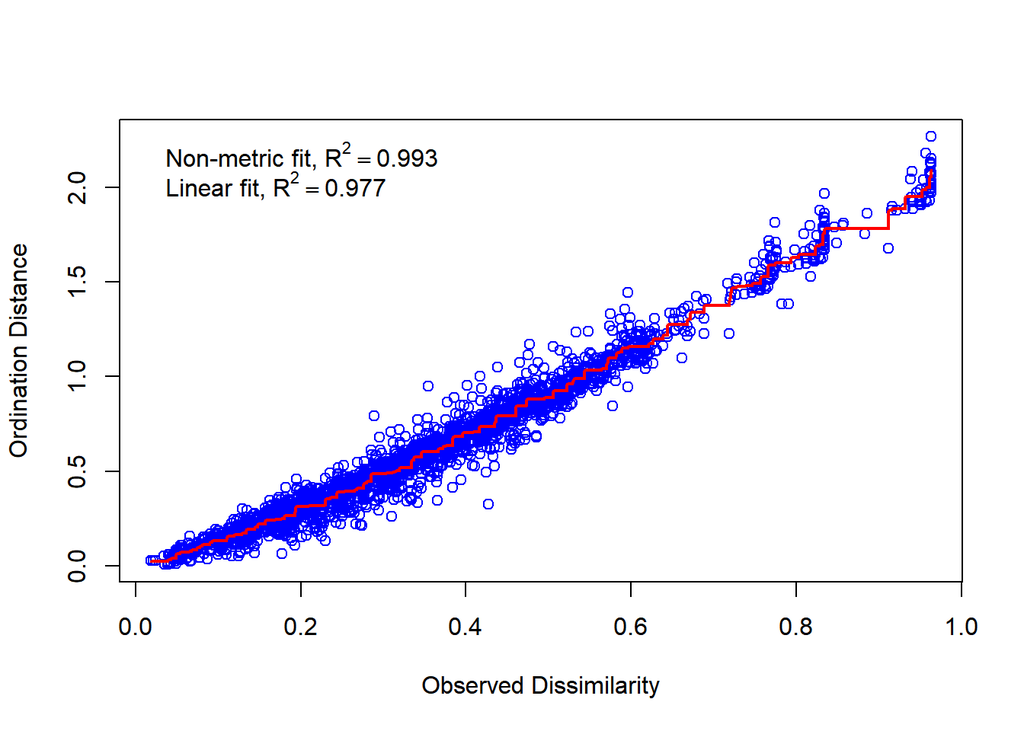

```r
stressplot(cov_nmds_br) #evaluating NMDS mapping: stressplot
```

```r
cov_nmds_br_gof=goodness(cov_nmds_br) #evaluating NMDS mapping: goodness of fit
cov_nmds_br_gof #smaller the value, the lower stress and better fit
```

```
##  [1] 0.010207191 0.007770256 0.007434593 0.007915694 0.005889545 0.006703775
##  [7] 0.014457688 0.006898141 0.005909848 0.007016142 0.006966166 0.019152319
## [13] 0.013748865 0.013879682 0.012297642 0.013204348 0.013336372 0.012385183
## [19] 0.008552310 0.010405323 0.010446426 0.007227061 0.007539408 0.008666996
## [25] 0.010826635 0.010344015 0.014051115 0.007908929 0.006822348 0.009120105
## [31] 0.006806117 0.005737709 0.007716719 0.005665718 0.007050362 0.005703511
## [37] 0.010685927 0.006744443 0.020646664 0.011893429 0.010422738 0.019883814
## [43] 0.006334528 0.007657464 0.007360904 0.021041467 0.014356296 0.012127543
## [49] 0.012072444 0.010257395 0.006176043 0.007361126 0.007139727 0.009614350
## [55] 0.007524368 0.007718481 0.006790863 0.009047887 0.006494318 0.005822469
## [61] 0.005826903 0.007530007 0.006817530 0.006864817 0.007773148 0.008449597
## [67] 0.009095556 0.007730760 0.007362365
```

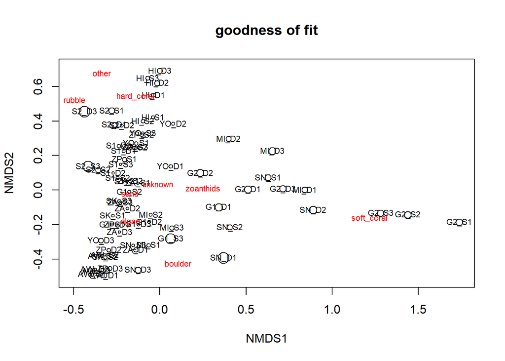

```r
plot(cov_nmds_br, type="t", main="goodness of fit") # create a plot for goodness of fit visualization:
points(cov_nmds_br, display="site", cex=cov_nmds_br_gof*100) #display the goodness of fit on the plot
```

```r
#Stress lesser, better (>0.2 poor,0.2-0.1 moderate,0.1-0.05 good,<0.05 excellent);
#K level higher, stress lesser
cov_nmds_br$stress
```

```
## [1] 0.08365719
```

Stress = 0.0836572 < 0.1, not excellent (<0.05), but still a good ordination

Check Stress for each additional dimension

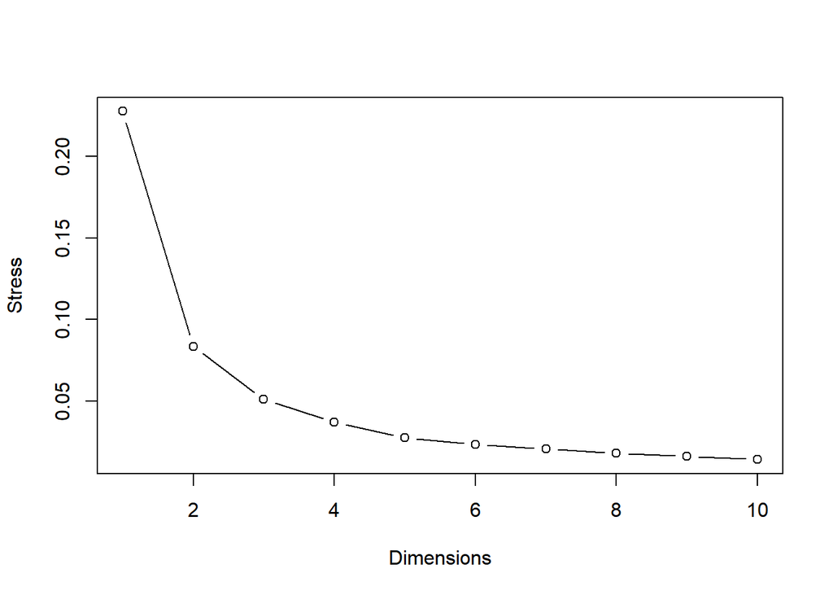

```r
k_vec=1:10
stress=numeric(length(k_vec))
relcov_dij=metaMDSdist(cov_mat, trace=FALSE)
set.seed(69)
for(i in seq_along(k_vec)) {
  cov_nmds_br_loop=metaMDSiter(relcov_dij, k=i, trace=FALSE)
  stress[i]=cov_nmds_br_loop$stress
}
plot(k_vec,stress,type="b",ylab="Stress",xlab="Dimensions") #select the K correspondent to the most drastic drop in stress
```

```r
rm(k_vec)
```

## 2.4 Plot the nMDS with basic R function `plot()`

```r
cov_nmds_br=metaMDS(cov_mat) #Run NMDS
```

```
## *** Best solution repeated 5 times
```

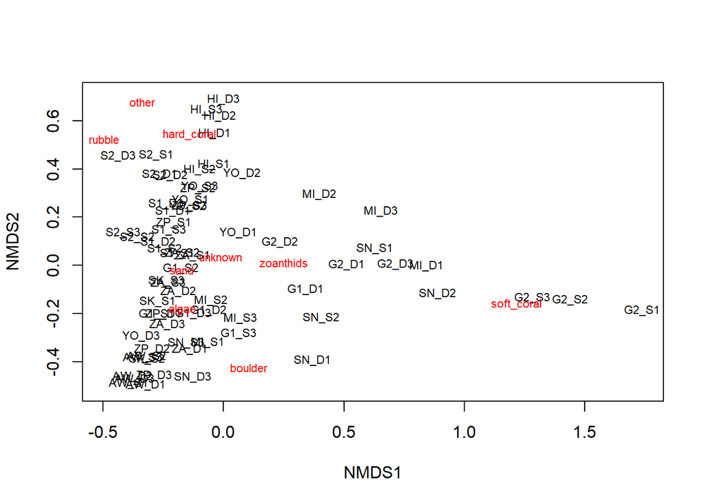

```r
plot(cov_nmds_br, type="text") #NMDS rough plot
```

```r
cov_nmds_br$stress
```

```
## [1] 0.08365719
```

## 2.5 nMDS plot with `ggplot() and` with `geom_mark_ellipse()` from `ggforce`

Create input data frame with nMDS scores necessary for visualisation with `ggplot()`

```r
cov_ndms_scores <- as.data.frame(scores(cov_nmds_br)$sites)  #Using the scores function from vegan to extract the site scores and convert to a data.frame
cov_ndms_scores$transect <- rownames(cov_ndms_scores) # create a column of transect names
cov_ndms_scores$site <- ind_df$Site
cov_ndms_scores$Depth <- ind_df$Depth  #  add the grp variable created earlier
str(cov_ndms_scores)  #look at the data
```

```
## 'data.frame':    69 obs. of  5 variables:
##  $ NMDS1   : num  -0.324 -0.377 -0.37 -0.393 -0.319 ...
##  $ NMDS2   : num  -0.495 -0.462 -0.473 -0.49 -0.377 ...
##  $ transect: chr  "AW_D1" "AW_D2" "AW_D3" "AW_S1" ...
##  $ site    : Ord.factor w/ 12 levels "HI"<"S1"<"S2"<..: 10 10 10 10 10 10 11 11 11 11 ...
##  $ Depth   : Factor w/ 2 levels "Deep","Shallow": 1 1 1 2 2 2 1 1 1 2 ...
```

```r
NMDS1 <- cov_nmds_br$points[,1] ##also found using: > scores(cov_nmds_br)
NMDS2 <- cov_nmds_br$points[,2]
nmds_df<-cbind(ind_df, NMDS1, NMDS2)
rm(NMDS1,NMDS2)
```

nMDS plot

```r
str(cov_nmds_br)
```

```
## List of 36
##  $ nobj      : int 69
##  $ nfix      : int 0
##  $ ndim      : num 2
##  $ ndis      : int 2346
##  $ ngrp      : int 1
##  $ diss      : num [1:2346] 0.0185 0.021 0.024 0.034 0.0355 ...
##  $ iidx      : int [1:2346] 56 64 4 65 69 68 60 6 24 44 ...
##  $ jidx      : int [1:2346] 55 10 3 6 56 57 10 5 20 6 ...
##  $ xinit     : num [1:138] 0.137 0.15 0.151 0.155 0.146 ...
##  $ istart    : int 1
##  $ isform    : int 1
##  $ ities     : int 1
##  $ iregn     : int 1
##  $ iscal     : int 1
##  $ maxits    : int 200
##  $ sratmx    : num 1
##  $ strmin    : num 1e-04
##  $ sfgrmn    : num 1e-07
##  $ dist      : num [1:2346] 0.0273 0.0288 0.0291 0.0518 0.0081 ...
##  $ dhat      : num [1:2346] 0.0259 0.0259 0.0259 0.0259 0.0259 ...
##  $ points    : num [1:69, 1:2] -0.324 -0.377 -0.37 -0.393 -0.319 ...
##   ..- attr(*, "dimnames")=List of 2
##   .. ..$ : chr [1:69] "AW_D1" "AW_D2" "AW_D3" "AW_S1" ...
##   .. ..$ : chr [1:2] "MDS1" "MDS2"
##   ..- attr(*, "centre")= logi TRUE
##   ..- attr(*, "pc")= logi TRUE
##   ..- attr(*, "halfchange")= logi TRUE
##   ..- attr(*, "internalscaling")= num 1.86
##  $ stress    : num 0.0837
##  $ grstress  : num 0.0837
##  $ iters     : int 31
##  $ icause    : int 4
##  $ call      : language metaMDS(comm = cov_mat)
##  $ model     : chr "global"
##  $ distmethod: chr "bray"
##  $ distcall  : chr "vegdist(x = comm, method = distance)"
##  $ data      : chr "cov_mat"
##  $ distance  : chr "bray"
##  $ converged : num 5
##  $ tries     : num 20
##  $ bestry    : num 0
##  $ engine    : chr "monoMDS"
##  $ species   : num [1:9, 1:2] -0.171 0.105 -0.14 -0.336 -0.496 ...
##   ..- attr(*, "dimnames")=List of 2
##   .. ..$ : chr [1:9] "algae" "boulder" "hard_coral" "other" ...
##   .. ..$ : chr [1:2] "MDS1" "MDS2"
##   ..- attr(*, "shrinkage")= Named num [1:2] 0.43 0.145
##   .. ..- attr(*, "names")= chr [1:2] "MDS1" "MDS2"
##   ..- attr(*, "centre")= Named num [1:2] 3.99e-05 -2.24e-05
##   .. ..- attr(*, "names")= chr [1:2] "MDS1" "MDS2"
##  - attr(*, "class")= chr [1:2] "metaMDS" "monoMDS"
```

[figure not shown]

```r
library(ggplot2)
#install.packages("ggforce")
library(ggforce)

cov_ndms_ggplot <- ggplot(nmds_df, aes(NMDS1, NMDS2))+
  geom_point(data=nmds_df, aes(NMDS1, NMDS2, color=Site, shape=Depth),size=3)+##separates overlapping points
  geom_mark_ellipse(aes(fill=Site, color=Site), expand = 0)+ # https://luisdva.github.io/rstats/Grouping-points/
  theme_classic()+
  ggtitle("nMDS of relative benthic cover")+
  theme(plot.title = element_text(size=14, face="bold",hjust=.5),
        legend.title = element_text(color = "black", size = 12),
        legend.text = element_text(size=10))+
  guides(color = guide_legend(order = 1,title="Site"),
         fill = guide_legend(order = 1,title="Site"),
         shape = guide_legend(order = 2,title="Depth"))+
  annotate("text", x=-0.45, y=-0.9,
           label=paste('Stress =',round(cov_nmds_br$stress,3)),
           size=4)+
  annotate("text", x=-0.35, y=-1,
           label=bquote('Non-metric fit,'~ R^2~"= 0.998"),
           size=4) #add goodness of fit to plot

cov_ndms_ggplot
```

nMDS with ellipses based on the pressure level

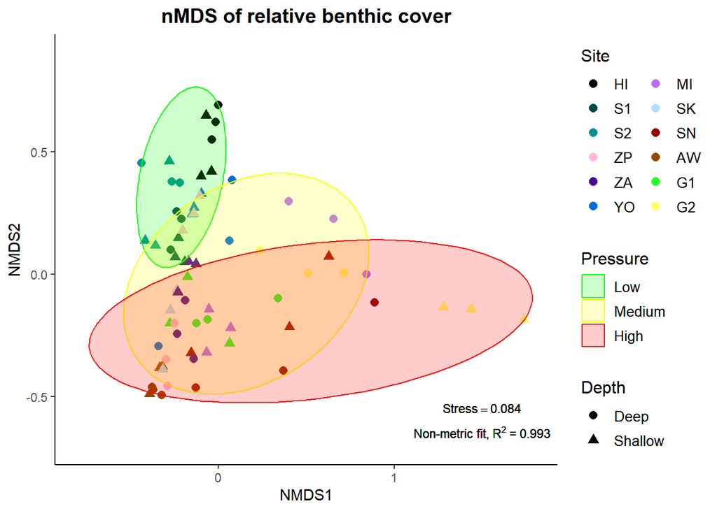

```r
pal12 <- c("#000000","#004949","#009292","#ffb6db",
 "#490092","#006ddb","#b66dff","#b6dbff",
 "#920000","#924900","#24ff24","#ffff6d") #Cols from https://stackoverflow.com/questions/65013406/how-to-generate-30-distinct-colors-that-are-color-blind-friendly

library(ggnewscale) #necessary for new_scale_color

ggplot(nmds_df, aes(NMDS1, NMDS2))+
  geom_point(data=nmds_df, aes(NMDS1, NMDS2, color=Site, shape=Depth),size=2.5)+##separates overlapping points
  scale_color_manual(values= pal12)+
  guides(color= guide_legend(order=1, title = "Site", ncol =2))+
  new_scale_color() +
  geom_mark_ellipse(aes(fill=Pressure, color=Pressure), expand = 0, alpha=0.2)+ # https://luisdva.github.io/rstats/Grouping-points/
  scale_color_manual(values= c("green","yellow","red"))+
  scale_fill_manual(values= c("green","yellow","red"))+
  theme_classic()+
  ggtitle("nMDS of relative benthic cover")+
  theme(plot.title = element_text(size=14, face="bold",hjust=.5),
        legend.title = element_text(color = "black", size = 12),
        legend.text = element_text(size=10))+
  scale_x_continuous(limits = c(-.8,1.8))+
  scale_y_continuous(limits = c(-.7,.9))+
  annotate("text", x=1.5, y=-0.6,
           label=bquote(atop(Stress == .(round(cov_nmds_br$stress,3)),
                             'Non-metric fit,'~ R^2~"= 0.993")),
           size=3) #add goodness of fit to plot
```

```r
rm(pal12)
```

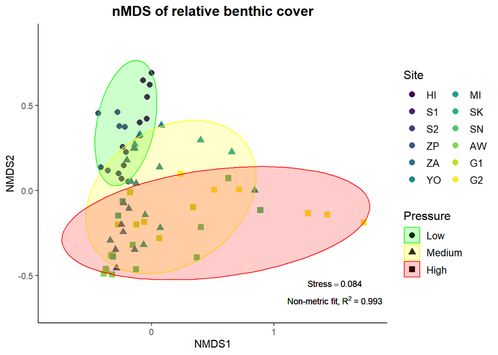

```r
library(ggnewscale) #necessary for new_scale_color

ggplot(nmds_df, aes(NMDS1, NMDS2))+
  geom_point(data=nmds_df, aes(NMDS1, NMDS2, color=Site, shape=Pressure),size=2.5)+##separates overlapping points
  guides(color= guide_legend(order=1, title = "Site", ncol =2))+
  new_scale_color() +
  geom_mark_ellipse(aes(fill=Pressure, color=Pressure), expand = 0, alpha=0.2)+ # https://luisdva.github.io/rstats/Grouping-points/
  scale_color_manual(values= c("green","yellow","red"))+
  scale_fill_manual(values= c("green","yellow","red"))+
  theme_classic()+
  ggtitle("nMDS of relative benthic cover")+
  theme(plot.title = element_text(size=14, face="bold",hjust=.5),
        legend.title = element_text(color = "black", size = 12),
        legend.text = element_text(size=10))+
  scale_x_continuous(limits = c(-.8,1.8))+
  scale_y_continuous(limits = c(-.7,.9))+
    annotate("text", x=1.5, y=-0.6,
           label=bquote(atop(Stress == .(round(cov_nmds_br$stress,3)),
                             'Non-metric fit,'~ R^2~"= 0.993")),
           size=3) #add goodness of fit to plot
```

```r
ggsave("ndms_relcov_pressure.tiff",
       units ="in", width = 5, height = 4, dpi = 300, compression = 'lzw',
       path = here("Multi-taxa_data","PLITs","4-Visualization_outputs"))
```

# 3 PERMANOVA AND POST-HOC PAIRWISE PERMANOVA

Load libraries

```r
#VEGAN----
library(vegan)#load package
library(MASS)
library(dplyr)

#install.packages("pairwiseAdonis")
library(devtools) #to install pairwiseAdonis from GitHub
library(pairwiseAdonis)
#install.packages("Rtools")
# library(remotes) #to use install_github
# install_github("pmartinezarbizu/pairwiseAdonis/pairwiseAdonis")
library(pairwiseAdonis)

library(readxl)   # to import excel datasets
```

Load and format data

```r
#Relative benthic cover dataframe

cov_df <- read_excel(here("Multi-taxa_data","PLITs","3-Clean_data","Rel_cov_input.xlsx"))
str(cov_df)
```

```
## tibble [69 × 24] (S3: tbl_df/tbl/data.frame)
##  $ Transect  : chr [1:69] "AW_D1" "AW_D2" "AW_D3" "AW_S1" ...
##  $ Site      : chr [1:69] "AW" "AW" "AW" "AW" ...
##  $ Depth_rep : chr [1:69] "D1" "D2" "D3" "S1" ...
##  $ depth     : chr [1:69] "Deep" "Deep" "Deep" "Shallow" ...
##  $ Site_depth: chr [1:69] "AW_Deep" "AW_Deep" "AW_Deep" "AW_Shallow" ...
##  $ Replicate : chr [1:69] "1" "2" "3" "1" ...
##  $ algae     : num [1:69] 0.85 0.92 0.934 0.953 0.874 0.899 0.497 0.691 0.734 0.8 ...
##  $ boulder   : num [1:69] 0.018 0 0.01 0 0.023 0 0 0 0 0 ...
##  $ hard_coral: num [1:69] 0 0.018 0.026 0.023 0.073 0.075 0.104 0.143 0.152 0.167 ...
##  $ other     : num [1:69] 0 0.001 0 0 0 0 0 0 0 0 ...
##  $ rubble    : num [1:69] 0.059 0.004 0.014 0.019 0.001 0.01 0.005 0.012 0 0 ...
##  $ sand      : num [1:69] 0.047 0.042 0.006 0.003 0.024 0.008 0.096 0.036 0.014 0 ...
##  $ soft_coral: num [1:69] 0.023 0.001 0 0 0.001 0.002 0.276 0.107 0.077 0 ...
##  $ unknown   : num [1:69] 0.003 0.014 0.009 0.001 0.004 0.003 0.023 0.01 0.024 0.033 ...
##  $ zoanthids : num [1:69] 0 0 0 0 0 0.003 0 0 0 0 ...
##  $ sd_alg    : num [1:69] 0.05 0.05 0.05 0.04 0.04 0.04 0.13 0.13 0.13 0.1 ...
##  $ sd_boulder: num [1:69] 0.01 0.01 0.01 0.01 0.01 0.01 0 0 0 0 ...
##  $ sd_hc     : num [1:69] 0.01 0.01 0.01 0.03 0.03 0.03 0.03 0.03 0.03 0.08 ...
##  $ sd_other  : num [1:69] 0 0 0 0 0 0 0 0 0 0 ...
##  $ sd_rubble : num [1:69] 0.03 0.03 0.03 0.01 0.01 0.01 0.01 0.01 0.01 0 ...
##  $ sd_sand   : num [1:69] 0.02 0.02 0.02 0.01 0.01 0.01 0.04 0.04 0.04 0 ...
##  $ sd_softc  : num [1:69] 0.01 0.01 0.01 0 0 0 0.11 0.11 0.11 0.03 ...
##  $ sd_unknown: num [1:69] 0.01 0.01 0.01 0 0 0 0.01 0.01 0.01 0.01 ...
##  $ sd_zoanth : num [1:69] 0 0 0 0 0 0 0 0 0 0.12 ...
```

```r
cov_df <- cov_df %>%
  mutate(Pressure = case_when(Site == 'HI' |
                              Site == "S1" |
                              Site == "S2" ~ "Low",
                              Site == "ZP" |
                              Site == 'ZA' |
                              Site == "YO" |
                              Site == "MI" ~ "Medium",
                              Site == 'SK' |
                              Site == 'SN' |
                              Site == "AW" |
                              Site == "G1" |
                              Site == "G2"~ "High")) %>%
  rename(Depth = depth)

cov_df <- cov_df[ ,c(1:6, 25, 7:24)]

cov_df$Site<-ordered(cov_df$Site,levels=c("HI", "S1", "S2", "ZP", "ZA", "YO", "MI","SK", "SN", "AW", "G1", "G2"))

cov_df$Pressure<-ordered(cov_df$Pressure,levels=c("Low", "Medium", "High"))

cov_df[,c(1,3:6)] <- lapply(cov_df[,c(1,3:6)], as.factor)  ## as.factor() could also be used

cov_df[,8:25] <- lapply(cov_df[,8:25], as.numeric)

cov_df <- cov_df[,-c(17:25)]

str(cov_df)
```

```
## tibble [69 × 16] (S3: tbl_df/tbl/data.frame)
##  $ Transect  : Factor w/ 69 levels "AW_D1","AW_D2",..: 1 2 3 4 5 6 7 8 9 10 ...
##  $ Site      : Ord.factor w/ 12 levels "HI"<"S1"<"S2"<..: 10 10 10 10 10 10 11 11 11 11 ...
##  $ Depth_rep : Factor w/ 6 levels "D1","D2","D3",..: 1 2 3 4 5 6 1 2 3 4 ...
##  $ Depth     : Factor w/ 2 levels "Deep","Shallow": 1 1 1 2 2 2 1 1 1 2 ...
##  $ Site_depth: Factor w/ 23 levels "AW_Deep","AW_Shallow",..: 1 1 1 2 2 2 3 3 3 4 ...
##  $ Replicate : Factor w/ 3 levels "1","2","3": 1 2 3 1 2 3 1 2 3 1 ...
##  $ Pressure  : Ord.factor w/ 3 levels "Low"<"Medium"<..: 3 3 3 3 3 3 3 3 3 3 ...
##  $ algae     : num [1:69] 0.85 0.92 0.934 0.953 0.874 0.899 0.497 0.691 0.734 0.8 ...
##  $ boulder   : num [1:69] 0.018 0 0.01 0 0.023 0 0 0 0 0 ...
##  $ hard_coral: num [1:69] 0 0.018 0.026 0.023 0.073 0.075 0.104 0.143 0.152 0.167 ...
##  $ other     : num [1:69] 0 0.001 0 0 0 0 0 0 0 0 ...
##  $ rubble    : num [1:69] 0.059 0.004 0.014 0.019 0.001 0.01 0.005 0.012 0 0 ...
##  $ sand      : num [1:69] 0.047 0.042 0.006 0.003 0.024 0.008 0.096 0.036 0.014 0 ...
##  $ soft_coral: num [1:69] 0.023 0.001 0 0 0.001 0.002 0.276 0.107 0.077 0 ...
##  $ unknown   : num [1:69] 0.003 0.014 0.009 0.001 0.004 0.003 0.023 0.01 0.024 0.033 ...
##  $ zoanthids : num [1:69] 0 0 0 0 0 0.003 0 0 0 0 ...
```

```r
#create a df with the independent variables
ind_df <- as.data.frame(cov_df[,c(1:7)])
str(ind_df)
```

```
## 'data.frame':    69 obs. of  7 variables:
##  $ Transect  : Factor w/ 69 levels "AW_D1","AW_D2",..: 1 2 3 4 5 6 7 8 9 10 ...
##  $ Site      : Ord.factor w/ 12 levels "HI"<"S1"<"S2"<..: 10 10 10 10 10 10 11 11 11 11 ...
##  $ Depth_rep : Factor w/ 6 levels "D1","D2","D3",..: 1 2 3 4 5 6 1 2 3 4 ...
##  $ Depth     : Factor w/ 2 levels "Deep","Shallow": 1 1 1 2 2 2 1 1 1 2 ...
##  $ Site_depth: Factor w/ 23 levels "AW_Deep","AW_Shallow",..: 1 1 1 2 2 2 3 3 3 4 ...
##  $ Replicate : Factor w/ 3 levels "1","2","3": 1 2 3 1 2 3 1 2 3 1 ...
##  $ Pressure  : Ord.factor w/ 3 levels "Low"<"Medium"<..: 3 3 3 3 3 3 3 3 3 3 ...
```

Convert the database `cov_df`to a matrix

```r
cov_mat <- cov_df[,-c(1:7)]
rownames(cov_mat) <- cov_df$Transect
cov_mat <- as.matrix(cov_mat)
str(cov_mat)
```

```
##  num [1:69, 1:9] 0.85 0.92 0.934 0.953 0.874 0.899 0.497 0.691 0.734 0.8 ...
##  - attr(*, "dimnames")=List of 2
##   ..$ : chr [1:69] "AW_D1" "AW_D2" "AW_D3" "AW_S1" ...
##   ..$ : chr [1:9] "algae" "boulder" "hard_coral" "other" ...
```

```r
class(cov_mat)
```

```
## [1] "matrix" "array"
```

Create a df with explanatory (independent) variables

```r
ind_df <- as.data.frame(cov_df[,c(1:7)])
str(ind_df)
```

```
## 'data.frame':    69 obs. of  7 variables:
##  $ Transect  : Factor w/ 69 levels "AW_D1","AW_D2",..: 1 2 3 4 5 6 7 8 9 10 ...
##  $ Site      : Ord.factor w/ 12 levels "HI"<"S1"<"S2"<..: 10 10 10 10 10 10 11 11 11 11 ...
##  $ Depth_rep : Factor w/ 6 levels "D1","D2","D3",..: 1 2 3 4 5 6 1 2 3 4 ...
##  $ Depth     : Factor w/ 2 levels "Deep","Shallow": 1 1 1 2 2 2 1 1 1 2 ...
##  $ Site_depth: Factor w/ 23 levels "AW_Deep","AW_Shallow",..: 1 1 1 2 2 2 3 3 3 4 ...
##  $ Replicate : Factor w/ 3 levels "1","2","3": 1 2 3 1 2 3 1 2 3 1 ...
##  $ Pressure  : Ord.factor w/ 3 levels "Low"<"Medium"<..: 3 3 3 3 3 3 3 3 3 3 ...
```

## 3.1 PERMANOVA among the 12 sites

### 3.1.1 Question 1: is there a significant difference in benthic cover among sites?

```r
set.seed(69)
perm=how(nperm=999)
relcov_site_pmv=adonis2(cov_mat~Site,
                        data=ind_df,
                        permutations =perm,
                        methods="bray",
                        by = "margin")

relcov_site_pmv
```

```
## Permutation test for adonis under reduced model
## Marginal effects of terms
## Permutation: free
## Number of permutations: 999
##
## adonis2(formula = cov_mat ~ Site, data = ind_df, permutations = perm, by = "margin", methods = "bray")
##          Df SumOfSqs      R2      F Pr(>F)
## Site     11   3.9659 0.68761 11.406  0.001 ***
## Residual 57   1.8018 0.31239
## Total    68   5.7677 1.00000
## ---
## Signif. codes:  0 '***' 0.001 '**' 0.01 '*' 0.05 '.' 0.1 ' ' 1
```

P-value 0.001 < 0.05, so there is a significant difference among sites.

### 3.1.2 Question 2: is there a significant difference in benthic cover between depth withing sites?

```r
#SCRIPT WITH adonis()
set.seed(69)
perm=how(nperm=999)
relcov_Depth_pmv <- adonis(cov_mat~Depth,
                           data=ind_df,
                           permutations =perm,
                           strata=ind_df$Site,
                           methods="bray",
                           by = "margin")
```

```
## 'adonis' will be deprecated: use 'adonis2' instead
```

```r
relcov_Depth_pmv$aov.tab
```

```
## Blocks:  strata
## Permutation: free
## Number of permutations: 999
##
## Terms added sequentially (first to last)
##
##           Df SumsOfSqs  MeanSqs F.Model      R2 Pr(>F)
## Depth      1    0.0155 0.015474 0.18023 0.00268  0.754
## Residuals 67    5.7522 0.085854         0.99732
## Total     68    5.7677                  1.00000
```

```r
#ALTERNATIVE SCRIPT WITH adonis2()
set.seed(69)
h <- how(blocks = ind_df$Site, nperm = 999)
relcov_blocks_pmv <- adonis2(cov_mat~Depth,
                             data=ind_df,
                             permutations =h,
                             methods="bray",
                             by = "margin")

relcov_blocks_pmv
```

```
## Permutation test for adonis under reduced model
## Marginal effects of terms
## Blocks:  ind_df$Site
## Permutation: free
## Number of permutations: 999
##
## adonis2(formula = cov_mat ~ Depth, data = ind_df, permutations = h, by = "margin", methods = "bray")
##          Df SumOfSqs      R2      F Pr(>F)
## Depth     1   0.0155 0.00268 0.1802  0.754
## Residual 67   5.7522 0.99732
## Total    68   5.7677 1.00000
```

### 3.1.3 Question 3: is there a significant difference in relative benthic cover among anthropogenic pressure level?

```r
set.seed(69)
perm=how(nperm=999)
relcov_pressure_pmv=adonis2(cov_mat~Pressure,
                        data=ind_df,
                        permutations =perm,
                        methods="bray",
                        by = "margin")

relcov_pressure_pmv
```

```
## Permutation test for adonis under reduced model
## Marginal effects of terms
## Permutation: free
## Number of permutations: 999
##
## adonis2(formula = cov_mat ~ Pressure, data = ind_df, permutations = perm, by = "margin", methods = "bray")
##          Df SumOfSqs      R2      F Pr(>F)
## Pressure  2   1.3140 0.22782 9.7361  0.001 ***
## Residual 66   4.4537 0.77218
## Total    68   5.7677 1.00000
## ---
## Signif. codes:  0 '***' 0.001 '**' 0.01 '*' 0.05 '.' 0.1 ' ' 1
```

### 3.1.4 Question 4: is there a significant difference in relative benthic cover abundance among sites within pressure levels?

```r
#SCRIPT WITH adonis()
set.seed(69)
perm=how(nperm=999)
relcov_site_pressure_pmv <- adonis(cov_mat~Site,
                           data=ind_df,
                           permutations =perm,
                           strata=ind_df$Pressure,
                           methods="bray",
                           by = "margin")
```

```
## 'adonis' will be deprecated: use 'adonis2' instead
```

```r
relcov_site_pressure_pmv$aov.tab
```

```
## Blocks:  strata
## Permutation: free
## Number of permutations: 999
##
## Terms added sequentially (first to last)
##
##           Df SumsOfSqs MeanSqs F.Model      R2 Pr(>F)
## Site      11    3.9659 0.36054  11.406 0.68761  0.001 ***
## Residuals 57    1.8018 0.03161         0.31239
## Total     68    5.7677                 1.00000
## ---
## Signif. codes:  0 '***' 0.001 '**' 0.01 '*' 0.05 '.' 0.1 ' ' 1
```

```r
#ALTERNATIVE SCRIPT WITH adonis2()
set.seed(69)
h <- how(blocks = ind_df$Pressure, nperm = 999)
relcov_site_pressure_pmv <- adonis2(cov_mat~Site,
                             data=ind_df,
                             permutations =h,
                             methods="bray",
                             by = "margin")

relcov_site_pressure_pmv
```

```
## Permutation test for adonis under reduced model
## Marginal effects of terms
## Blocks:  ind_df$Pressure
## Permutation: free
## Number of permutations: 999
##
## adonis2(formula = cov_mat ~ Site, data = ind_df, permutations = h, by = "margin", methods = "bray")
##          Df SumOfSqs      R2      F Pr(>F)
## Site     11   3.9659 0.68761 11.406  0.001 ***
## Residual 57   1.8018 0.31239
## Total    68   5.7677 1.00000
## ---
## Signif. codes:  0 '***' 0.001 '**' 0.01 '*' 0.05 '.' 0.1 ' ' 1
```

## 3.2 Permutation test of multivariate homogeneity of groups dispersions (variances)

Theoretical explanation from Anderson, Marti, Ray N. Gorley, and Robert K. Clarke. Permanova+ for primer: Guide to software and statistical methods. Primer-E Limited, 2008: *In the case of a one-way analysis, the PERMANOVA test using permutations assumes only that the samples are exchangeable under a true null hypothesis12. The assumption of exchangeability is tantamount to assuming that the multivariate observations (samples) are independent and identically distributed (i.i.d.) under a true null hypothesis. Thus, although there are no explicit assumptions regarding the distributions of the original variables (they are certainly not assumed to be normally distributed), independence and homogeneity of dispersions (in the space of the resemblance measure) are directly implied by the permutation procedure. Clearly, if samples have very different dispersions in different groups, then they are not really exchangeable. Also, if the samples are unequally correlated with one another (e.g., temporally or spatially), then randomly shuffling them will destroy this kind of inherent structure.*

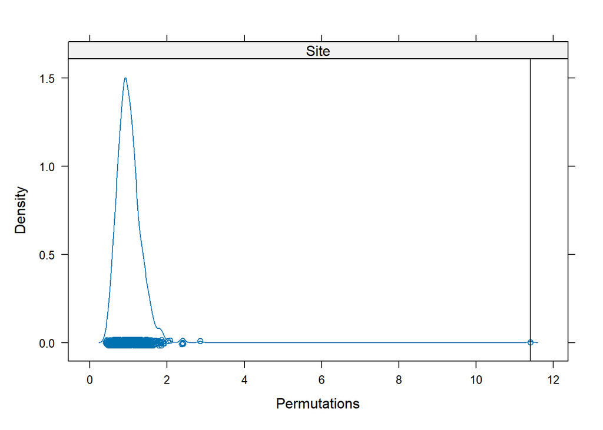

```r
set.seed(69)
densityplot(permustats(relcov_site_pmv)) #density plot of permutation results to to check if assumptions are met?
```

```r
relcov_dist = vegdist(cov_mat,method="bray")

relcov_bd=betadisper(relcov_dist,ind_df$Site)  #Implements Marti Anderson's PERMDISP2 procedure for the analysis of multivariate homogeneity of group dispersions (variances). betadisper is a multivariate analogue of Levene's test for homogeneity of variances
str(relcov_bd)
```

```
## List of 7
##  $ eig            : Named num [1:68] 3.063 1.861 0.358 0.347 0.24 ...
##   ..- attr(*, "names")= chr [1:68] "PCoA1" "PCoA2" "PCoA3" "PCoA4" ...
##  $ vectors        : num [1:69, 1:68] 0.137 0.15 0.151 0.155 0.146 ...
##   ..- attr(*, "dimnames")=List of 2
##   .. ..$ : chr [1:69] "AW_D1" "AW_D2" "AW_D3" "AW_S1" ...
##   .. ..$ : chr [1:68] "PCoA1" "PCoA2" "PCoA3" "PCoA4" ...
##  $ distances      : Named num [1:69] 0.1014 0.0311 0.0248 0.0433 0.0565 ...
##   ..- attr(*, "names")= chr [1:69] "AW_D1" "AW_D2" "AW_D3" "AW_S1" ...
##  $ group          : Ord.factor w/ 12 levels "HI"<"S1"<"S2"<..: 10 10 10 10 10 10 11 11 11 11 ...
##  $ centroids      : num [1:12, 1:68] 0.0252 0.1237 0.0833 0.1206 0.118 ...
##   ..- attr(*, "dimnames")=List of 2
##   .. ..$ : chr [1:12] "HI" "S1" "S2" "ZP" ...
##   .. ..$ : chr [1:68] "PCoA1" "PCoA2" "PCoA3" "PCoA4" ...
##  $ group.distances: num [1:12(1d)] 0.0641 0.0589 0.1097 0.1657 0.0839 ...
##   ..- attr(*, "dimnames")=List of 1
##   .. ..$ : chr [1:12] "HI" "S1" "S2" "ZP" ...
##  $ call           : language betadisper(d = relcov_dist, group = ind_df$Site)
##  - attr(*, "class")= chr "betadisper"
##  - attr(*, "method")= chr "bray"
##  - attr(*, "type")= chr "median"
##  - attr(*, "bias.adjust")= logi FALSE
```

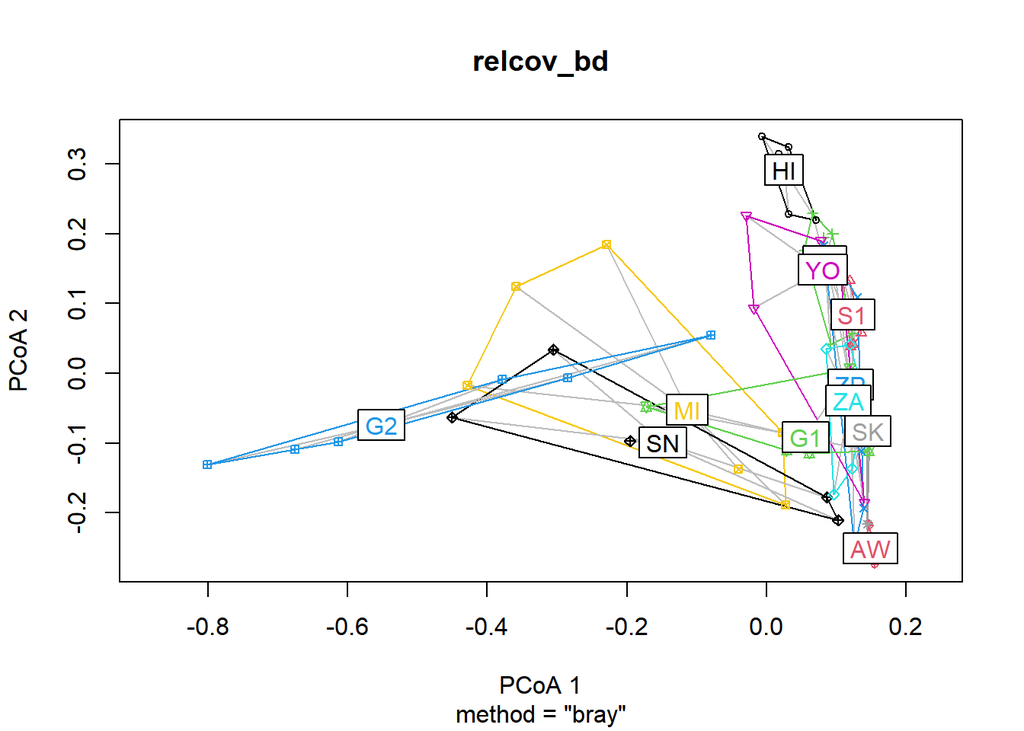

```r
plot(relcov_bd)
```

```r
anova(relcov_bd) #F-test on distribution of sites
```

```
## Analysis of Variance Table
##
## Response: Distances
##           Df  Sum Sq   Mean Sq F value   Pr(>F)
## Groups    11 0.30084 0.0273490  3.3931 0.001167 **
## Residuals 57 0.45943 0.0080601
## ---
## Signif. codes:  0 '***' 0.001 '**' 0.01 '*' 0.05 '.' 0.1 ' ' 1
```

### 3.2.1 Boxplot of within-site distance from centroid visualization with `ggplot()`

```r
relcov_bd$distances #Extract betadisper scores
```

```
##      AW_D1      AW_D2      AW_D3      AW_S1      AW_S2      AW_S3      G1_D1
## 0.10136930 0.03113239 0.02479788 0.04327342 0.05653784 0.03980927 0.27972412
##      G1_D2      G1_D3      G1_S1      G1_S2      G1_S3      G2_D1      G2_D2
## 0.04260982 0.00000000 0.11908310 0.13146688 0.20432566 0.28310218 0.55238046
##      G2_D3      G2_S1      G2_S2      G2_S3      HI_D1      HI_D2      HI_D3
## 0.21433132 0.27161089 0.13893922 0.06430689 0.05388728 0.02458117 0.06941924
##      HI_S1      HI_S2      HI_S3      MI_D1      MI_D2      MI_D3      MI_S1
## 0.08849058 0.09484741 0.05326772 0.32265745 0.22997906 0.28473362 0.19857397
##      MI_S2      MI_S3      S1_D1      S1_D2      S1_D3      S1_S1      S1_S2
## 0.14206767 0.09085121 0.06287289 0.06068050 0.08039450 0.06550371 0.07143073
##      S1_S3      S2_D1      S2_D2      S2_D3      S2_S1      S2_S2      S2_S3
## 0.01250730 0.08498530 0.12784889 0.12988576 0.04923268 0.12363684 0.14245890
##      SK_S1      SK_S2      SK_S3      SN_D1      SN_D2      SN_D3      SN_S1
## 0.00000000 0.13802750 0.06608278 0.15767174 0.35045879 0.26616365 0.21512575
##      SN_S2      SN_S3      YO_D1      YO_D2      YO_D3      YO_S1      YO_S2
## 0.00000000 0.27288946 0.16454954 0.15066530 0.37594093 0.00000000 0.00000000
##      YO_S3      ZA_D1      ZA_D2      ZA_D3      ZA_S1      ZA_S2      ZA_S3
## 0.06050886 0.15133157 0.02261626 0.12794897 0.09729340 0.08919021 0.01528376
##      ZP_D1      ZP_D2      ZP_D3      ZP_S1      ZP_S2      ZP_S3
## 0.09498816 0.17727912 0.22918328 0.12272137 0.20961216 0.16059402
```

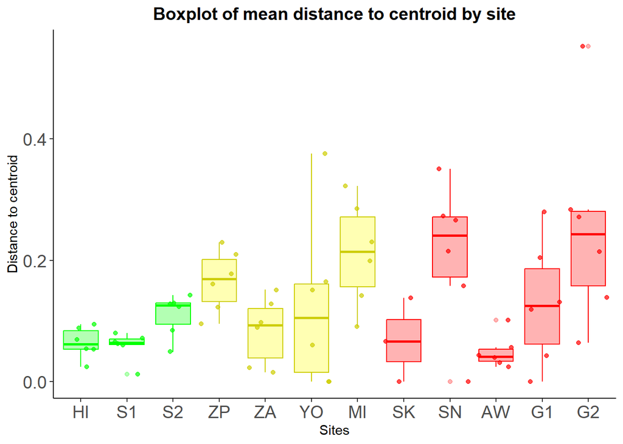

```r
distcent_df <- data.frame(Distance_to_centroid=relcov_bd$distances,Sites=ind_df$Site, Pressure=ind_df$Pressure)
Sites <- relcov_bd$group
distcent_df[,2]<-factor(distcent_df[,2],levels=c("HI", "S1", "S2", "ZP", "ZA", "YO", "MI","SK", "SN", "AW", "G1", "G2"))
distcent_df[,3]<-factor(distcent_df[,3],levels=c("Low","Medium","High"))

distcent_mean_df <- distcent_df %>%
  group_by(Sites) %>%
  summarise(`Mean distance to centroid`=round(mean(Distance_to_centroid),2),
         SD=round(mean(Distance_to_centroid),2)) %>%
  mutate(Pressure = case_when(Sites == 'HI' |
                              Sites == "S1" |
                              Sites == "S2" |
                              Sites == "ZP"~ "Low",
                              Sites == 'ZA' |
                              Sites == "YO" |
                              Sites == "MI" ~ "Medium",
                              Sites == 'SK' |
                              Sites == 'SN' |
                              Sites == "AW" |
                              Sites == "G1" |
                              Sites == "G2"~ "High"))

distcent_mean_df <- distcent_mean_df[,c(1,4,2,3)]

relcov_site_box <- ggplot(data=distcent_df,aes(x=Sites,y=Distance_to_centroid))+
  geom_boxplot(aes(fill=Pressure,colour=Pressure),alpha=0.3)+
  geom_jitter(aes(fill=Pressure,color=Pressure),alpha=0.7)+
  scale_fill_manual(values= c("green","yellow","red"))+
  scale_color_manual(values= c("green","yellow3","red"))+
  theme_classic()+
  labs(title="Boxplot of mean distance to centroid by site")+
  ylab(label="Distance to centroid")+
  theme(legend.position = "none", #remove legend
        plot.title  = element_text(hjust = 0.5, face= "bold", size =14),
        axis.text=element_text(size=14))

relcov_site_box
```

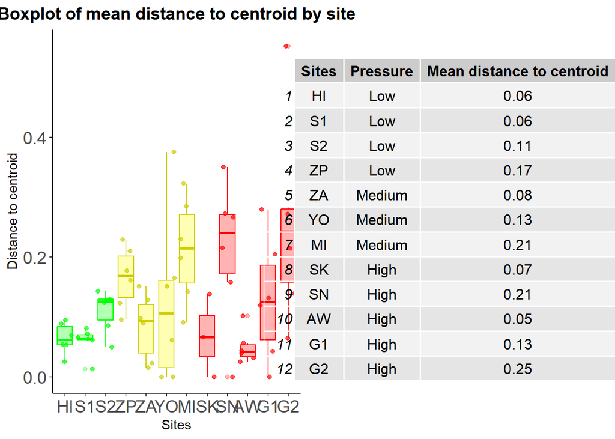

```r
ggpubr:: ggarrange(relcov_site_box,
                   gridExtra::tableGrob(distcent_mean_df),
                   ncol = 2, widths = c(1,1))
```

```r
ggsave("relcov_site_box.tiff",
       units="in", width=12, height=4, dpi=300, compression = 'lzw',
       path = here ("Multi-taxa_data","PLITs","4-Visualization_outputs"))
```

### 3.2.2 Permutest Implements a permutation-based test of multivariate homogeneity of group dispersions (variances)

```r
set.seed(69)
permutest(relcov_bd) #permutative test on dispersion based on sites, if significant, PERMANOVA results may be driven by  dispersion issue
```

```
##
## Permutation test for homogeneity of multivariate dispersions
## Permutation: free
## Number of permutations: 999
##
## Response: Distances
##           Df  Sum Sq   Mean Sq      F N.Perm Pr(>F)
## Groups    11 0.30084 0.0273490 3.3931    999  0.002 **
## Residuals 57 0.45943 0.0080601
## ---
## Signif. codes:  0 '***' 0.001 '**' 0.01 '*' 0.05 '.' 0.1 ' ' 1
```

```r
permutest(relcov_bd, pairwise=TRUE) #pairwise of dispersion test
```

```
##
## Permutation test for homogeneity of multivariate dispersions
## Permutation: free
## Number of permutations: 999
##
## Response: Distances
##           Df  Sum Sq   Mean Sq      F N.Perm Pr(>F)
## Groups    11 0.30084 0.0273490 3.3931    999  0.002 **
## Residuals 57 0.45943 0.0080601
## ---
## Signif. codes:  0 '***' 0.001 '**' 0.01 '*' 0.05 '.' 0.1 ' ' 1
##
## Pairwise comparisons:
## (Observed p-value below diagonal, permuted p-value above diagonal)
##            HI         S1         S2         ZP         ZA         YO         MI
## HI            0.75200000 0.02100000 0.00100000 0.46900000 0.32200000 0.00200000
## S1 0.72559985            0.01200000 0.00100000 0.34400000 0.29900000 0.00200000
## S2 0.02908209 0.01544279            0.03900000 0.37700000 0.79100000 0.02100000
## ZP 0.00142475 0.00090093 0.05124527            0.03100000 0.55500000 0.29100000
## ZA 0.44252508 0.33055177 0.35838755 0.02344683            0.55300000 0.01000000
## YO 0.32301999 0.28466680 0.79908054 0.52572409 0.52084854            0.23600000
## MI 0.00256279 0.00196173 0.02381809 0.29123932 0.01244110 0.23284264
## SK 0.89994933 0.76741543 0.25516183 0.04495436 0.71607135 0.53925843 0.04270418
## SN 0.01619584 0.01336227 0.07967268 0.42546977 0.04253730 0.29030088 0.98604584
## AW 0.36743526 0.54159946 0.00826586 0.00061009 0.20067048 0.22788055 0.00142265
## G1 0.16057179 0.13135669 0.66347299 0.45670755 0.36002021 0.95366587 0.16594876
## G2 0.02084537 0.01817789 0.06620972 0.24549805 0.04004023 0.18162771 0.59268573
##            SK         SN         AW         G1    G2
## HI 0.90500000 0.01700000 0.39100000 0.15400000 0.017
## S1 0.77600000 0.01200000 0.56400000 0.11400000 0.018
## S2 0.25300000 0.08100000 0.00900000 0.65200000 0.053
## ZP 0.04900000 0.43900000 0.00200000 0.48400000 0.228
## ZA 0.73900000 0.04200000 0.22200000 0.38800000 0.055
## YO 0.53300000 0.30900000 0.22800000 0.96500000 0.189
## MI 0.03800000 0.99500000 0.00100000 0.15200000 0.617
## SK            0.10700000 0.60800000 0.40600000 0.117
## SN 0.10737169            0.00700000 0.23800000 0.644
## AW 0.56698692 0.01006964            0.08700000 0.023
## G1 0.38664040 0.24114453 0.09468447            0.160
## G2 0.11580012 0.61646319 0.01465210 0.15198723
```

From Anderson, Marti, Ray N. Gorley, and Robert K. Clarke. Permanova+ for primer: Guide to software and statistical methods. Primer-E Limited, 2008: * If significant heterogeneity were detected by PERMDISP and differences among groups were also detected using PERMANOVA, then the latter could have been caused by differences in location, differences in dispersion, or some combination of the two. *

### 3.2.3 Post hoc test for PERMANOVA (`pairwise.adonis`)

```r
set.seed(69)
relcov_pmv_phoc_holm= pairwise.adonis(cov_mat,ind_df$Site,
                                  sim.function = "vegdist",
                                  sim.method = "bray",
                                  p.adjust.m = "holm",
                                  reduce = NULL)

relcov_pmv_phoc_holm
```

```
##       pairs Df  SumsOfSqs    F.Model        R2 p.value p.adjusted sig
## 1  AW vs G1  1 0.17588563 10.8160361 0.5196011   0.004      0.192
## 2  AW vs G2  2 1.27689738 11.6397068 0.7211845   0.004      0.192
## 3  AW vs HI  2 0.92783960 92.9801548 0.9538368   0.004      0.192
## 4  AW vs MI  1 0.54030452 17.9267677 0.6419206   0.004      0.192
## 5  AW vs S1  1 0.33777979 82.4970781 0.8918885   0.003      0.159
## 6  AW vs S2  2 0.55317542 26.2183772 0.8535079   0.002      0.126
## 7  AW vs SK  1 0.04615452  8.5258162 0.5491380   0.013      0.312
## 8  AW vs SN  1 0.44558722 12.9175954 0.5636540   0.004      0.192
## 9  AW vs YO  1 0.44054350 23.0771842 0.6976768   0.010      0.260
## 10 AW vs ZA  1 0.15866653 21.9723815 0.6872301   0.004      0.192
## 11 AW vs ZP  1 0.17458475  8.9538920 0.4724039   0.005      0.192
## 12 G1 vs G2  1 0.79688187 12.8373862 0.5621215   0.006      0.192
## 13 G1 vs HI  1 0.48018024 27.9178478 0.7362720   0.004      0.192
## 14 G1 vs MI  1 0.12999098  3.0337140 0.2327590   0.065      0.826
```

[output cut: 52 more lines]

```r
set.seed(69)
relcov_pmv_phoc_bonf= pairwise.adonis(cov_mat,ind_df$Site,
                                  sim.function = "vegdist",
                                  sim.method = "bray",
                                  p.adjust.m = "bonferroni",
                                  reduce = NULL)

relcov_pmv_phoc_bonf
```

```
##       pairs Df  SumsOfSqs    F.Model        R2 p.value p.adjusted sig
## 1  AW vs G1  1 0.17588563 10.8160361 0.5196011   0.004      0.264
## 2  AW vs G2  2 1.27689738 11.6397068 0.7211845   0.004      0.264
## 3  AW vs HI  2 0.92783960 92.9801548 0.9538368   0.004      0.264
## 4  AW vs MI  1 0.54030452 17.9267677 0.6419206   0.004      0.264
## 5  AW vs S1  1 0.33777979 82.4970781 0.8918885   0.003      0.198
## 6  AW vs S2  2 0.55317542 26.2183772 0.8535079   0.002      0.132
## 7  AW vs SK  1 0.04615452  8.5258162 0.5491380   0.013      0.858
## 8  AW vs SN  1 0.44558722 12.9175954 0.5636540   0.004      0.264
## 9  AW vs YO  1 0.44054350 23.0771842 0.6976768   0.010      0.660
## 10 AW vs ZA  1 0.15866653 21.9723815 0.6872301   0.004      0.264
## 11 AW vs ZP  1 0.17458475  8.9538920 0.4724039   0.005      0.330
## 12 G1 vs G2  1 0.79688187 12.8373862 0.5621215   0.006      0.396
## 13 G1 vs HI  1 0.48018024 27.9178478 0.7362720   0.004      0.264
## 14 G1 vs MI  1 0.12999098  3.0337140 0.2327590   0.065      1.000
```

[output cut: 52 more lines]

I can use Bonferroni because it is more conservative and it is the adjustment adopted for the other analyses.

N.B. `pairwise.adonis` and `pairwise.adonis2` have different syntaxes!

## 3.3 Permutation test of multivariate homogeneity of groups dispersions (variances)

Theoretical explanation from Anderson, Marti, Ray N. Gorley, and Robert K. Clarke. Permanova+ for primer: Guide to software and statisticl methods. Primer-E Limited, 2008: *In the case of a one-way analysis, the PERMANOVA test using permutations assumes only that the samples are exchangeable under a true null hypothesis12. The assumption of exchangeability is tantamount to assuming that the multivariate observations (samples) are independent and identically distributed (i.i.d.) under a true null hypothesis. Thus, although there are no explicit assumptions regarding the distributions of the original variables (they are certainly not assumed to be normally distributed), independence and homogeneity of dispersions (in the space of the resemblance measure) are directly implied by the permutation procedure. Clearly, if samples have very different dispersions in different groups, then they are not really exchangeable. Also, if the samples are unequally correlated with one another (e.g., temporally or spatially), then randomly shuffling them will destroy this kind of inherent structure.*

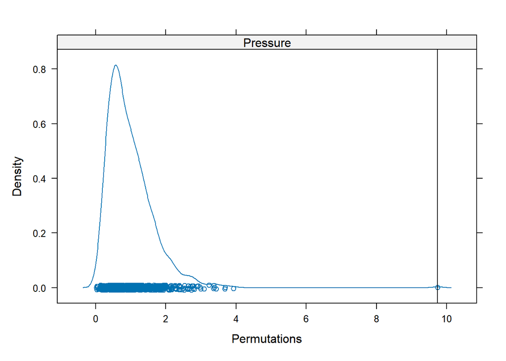

```r
set.seed(69)
densityplot(permustats(relcov_pressure_pmv)) #density plot of permutation results to to check if assumptions are met?
```

```r
relcov_dist = vegdist(cov_mat,method="bray")

relcov_bd_pres=betadisper(relcov_dist,ind_df$Pressure)  #Implements Marti Anderson's PERMDISP2 procedure for the analysis of multivariate homogeneity of group dispersions (variances). betadisper is a multivariate analogue of Levene's test for homogeneity of variances
str(relcov_bd_pres)
```

```
## List of 7
##  $ eig            : Named num [1:68] 3.063 1.861 0.358 0.347 0.24 ...
##   ..- attr(*, "names")= chr [1:68] "PCoA1" "PCoA2" "PCoA3" "PCoA4" ...
##  $ vectors        : num [1:69, 1:68] 0.137 0.15 0.151 0.155 0.146 ...
##   ..- attr(*, "dimnames")=List of 2
##   .. ..$ : chr [1:69] "AW_D1" "AW_D2" "AW_D3" "AW_S1" ...
##   .. ..$ : chr [1:68] "PCoA1" "PCoA2" "PCoA3" "PCoA4" ...
##  $ distances      : Named num [1:69] 0.214 0.211 0.214 0.229 0.17 ...
##   ..- attr(*, "names")= chr [1:69] "AW_D1" "AW_D2" "AW_D3" "AW_S1" ...
##  $ group          : Ord.factor w/ 3 levels "Low"<"Medium"<..: 3 3 3 3 3 3 3 3 3 3 ...
##  $ centroids      : num [1:3, 1:68] 0.0878 0.06656 0.01637 0.1606 0.00394 ...
##   ..- attr(*, "dimnames")=List of 2
##   .. ..$ : chr [1:3] "Low" "Medium" "High"
##   .. ..$ : chr [1:68] "PCoA1" "PCoA2" "PCoA3" "PCoA4" ...
##  $ group.distances: num [1:3(1d)] 0.151 0.194 0.283
##   ..- attr(*, "dimnames")=List of 1
##   .. ..$ : chr [1:3] "Low" "Medium" "High"
##  $ call           : language betadisper(d = relcov_dist, group = ind_df$Pressure)
##  - attr(*, "class")= chr "betadisper"
##  - attr(*, "method")= chr "bray"
##  - attr(*, "type")= chr "median"
##  - attr(*, "bias.adjust")= logi FALSE
```

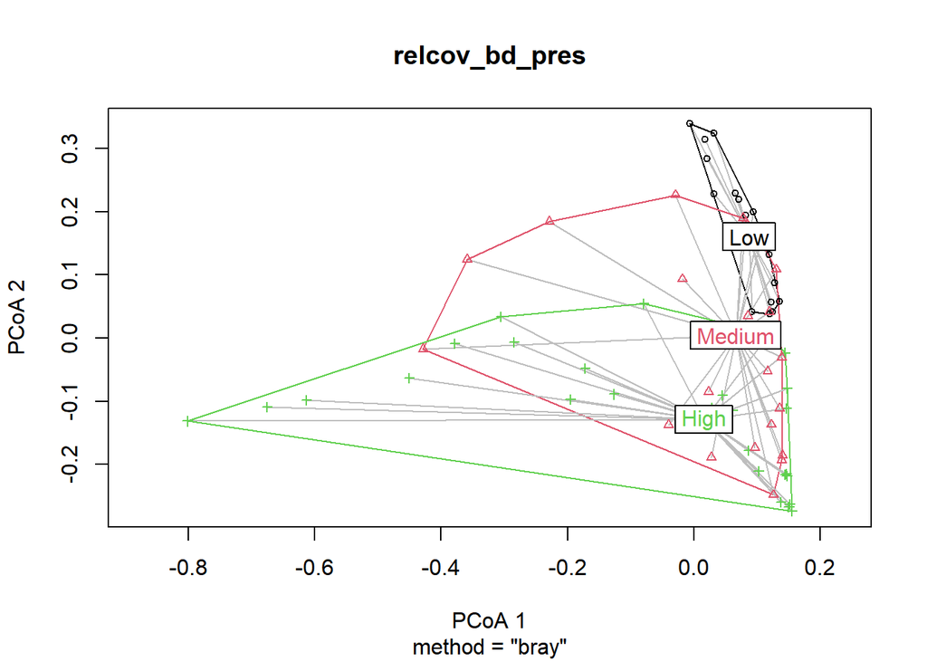

```r
plot(relcov_bd_pres)
```

```r
anova(relcov_bd_pres) #F-test on distribution of sites
```

```
## Analysis of Variance Table
##
## Response: Distances
##           Df Sum Sq  Mean Sq F value   Pr(>F)
## Groups     2 0.2081 0.104052   5.386 0.006812 **
## Residuals 66 1.2751 0.019319
## ---
## Signif. codes:  0 '***' 0.001 '**' 0.01 '*' 0.05 '.' 0.1 ' ' 1
```

### 3.3.1 Boxplot of within-site distance from centroid visualization with `ggplot()`

```r
relcov_bd_pres$distances #Extract betadisper scores
```

```
##      AW_D1      AW_D2      AW_D3      AW_S1      AW_S2      AW_S3      G1_D1
## 0.21437046 0.21050073 0.21358158 0.22932098 0.17016278 0.17736227 0.25448027
##      G1_D2      G1_D3      G1_S1      G1_S2      G1_S3      G2_D1      G2_D2
## 0.07515312 0.06952781 0.14312470 0.18341823 0.23138099 0.32403014 0.29241416
##      G2_D3      G2_S1      G2_S2      G2_S3      HI_D1      HI_D2      HI_D3
## 0.41522011 0.83468232 0.70343927 0.63726792 0.19179140 0.23771991 0.27054941
##      HI_S1      HI_S2      HI_S3      MI_D1      MI_D2      MI_D3      MI_S1
## 0.15156751 0.11590336 0.22974935 0.50371299 0.32832840 0.42423856 0.18699606
##      MI_S2      MI_S3      S1_D1      S1_D2      S1_D3      S1_S1      S1_S2
## 0.10697572 0.17710503 0.03841363 0.12377435 0.06074178 0.14119095 0.14846896
##      S1_S3      S2_D1      S2_D2      S2_D3      S2_S1      S2_S2      S2_S3
## 0.08024655 0.09533513 0.08161750 0.23472285 0.12834819 0.17323090 0.21914928
##      SK_S1      SK_S2      SK_S3      SN_D1      SN_D2      SN_D3      SN_S1
## 0.14281050 0.17379353 0.16985838 0.32852466 0.47853946 0.18321048 0.40093497
##      SN_S2      SN_S3      YO_D1      YO_D2      YO_D3      YO_S1      YO_S2
## 0.27880973 0.10457108 0.15012062 0.24956215 0.24586810 0.17112793 0.15734890
##      YO_S3      ZA_D1      ZA_D2      ZA_D3      ZA_S1      ZA_S2      ZA_S3
## 0.19715268 0.21139175 0.07390300 0.16029235 0.03502684 0.08273666 0.08244566
##      ZP_D1      ZP_D2      ZP_D3      ZP_S1      ZP_S2      ZP_S3
## 0.13836355 0.22345806 0.27340051 0.12230673 0.19684717 0.15556981
```

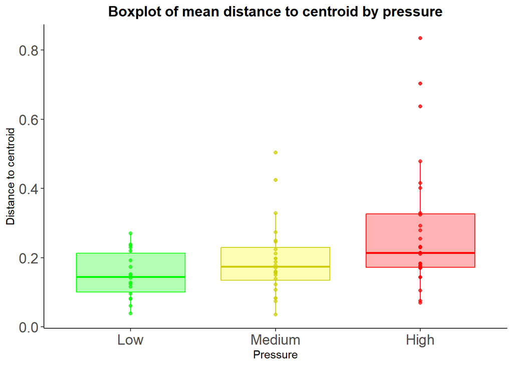

```r
distcent_df_pres <- data.frame(
  Distance_to_centroid=relcov_bd_pres$distances,
  Pressure=ind_df$Pressure)

distcent_df_pres$Pressure<-factor(distcent_df_pres$Pressure,
                             levels=c("Low","Medium","High"))

distcent_mean_df_pres <- distcent_df %>%
  group_by(Pressure) %>%
  summarise(`Mean distance to centroid`=round(mean(Distance_to_centroid),2),
         SD=round(mean(Distance_to_centroid),2))

relcov_pres_box <- ggplot(data=distcent_df_pres,aes(x=Pressure,y=Distance_to_centroid))+
  geom_boxplot(aes(fill=Pressure,colour=Pressure),alpha=0.3)+
  geom_point(aes(fill=Pressure,color=Pressure),alpha=0.7)+
  scale_fill_manual(values= c("green","yellow","red"))+
  scale_color_manual(values= c("green","yellow3","red"))+
  theme_classic()+
  labs(title="Boxplot of mean distance to centroid by pressure")+
  ylab(label="Distance to centroid")+
  theme(legend.position = "none", #remove legend
        plot.title  = element_text(hjust = 0.5, face= "bold", size =14),
        axis.text=element_text(size=14))

relcov_pres_box
```

### 3.3.2 Permutest Implements a permutation-based test of multivariate homogeneity of group dispersions (variances)

```r
set.seed(69)
permutest(relcov_bd) #permutative test on dispersion based on sites, if significant, PERMANOVA results may be driven by  dispersion issue
```

```
##
## Permutation test for homogeneity of multivariate dispersions
## Permutation: free
## Number of permutations: 999
##
## Response: Distances
##           Df  Sum Sq   Mean Sq      F N.Perm Pr(>F)
## Groups    11 0.30084 0.0273490 3.3931    999  0.002 **
## Residuals 57 0.45943 0.0080601
## ---
## Signif. codes:  0 '***' 0.001 '**' 0.01 '*' 0.05 '.' 0.1 ' ' 1
```

```r
permutest(relcov_bd, pairwise=TRUE) #pairwise of dispersion test
```

```
##
## Permutation test for homogeneity of multivariate dispersions
## Permutation: free
## Number of permutations: 999
##
## Response: Distances
##           Df  Sum Sq   Mean Sq      F N.Perm Pr(>F)
## Groups    11 0.30084 0.0273490 3.3931    999  0.002 **
## Residuals 57 0.45943 0.0080601
## ---
## Signif. codes:  0 '***' 0.001 '**' 0.01 '*' 0.05 '.' 0.1 ' ' 1
##
## Pairwise comparisons:
## (Observed p-value below diagonal, permuted p-value above diagonal)
##            HI         S1         S2         ZP         ZA         YO         MI
## HI            0.75200000 0.02100000 0.00100000 0.46900000 0.32200000 0.00200000
## S1 0.72559985            0.01200000 0.00100000 0.34400000 0.29900000 0.00200000
## S2 0.02908209 0.01544279            0.03900000 0.37700000 0.79100000 0.02100000
## ZP 0.00142475 0.00090093 0.05124527            0.03100000 0.55500000 0.29100000
## ZA 0.44252508 0.33055177 0.35838755 0.02344683            0.55300000 0.01000000
## YO 0.32301999 0.28466680 0.79908054 0.52572409 0.52084854            0.23600000
## MI 0.00256279 0.00196173 0.02381809 0.29123932 0.01244110 0.23284264
## SK 0.89994933 0.76741543 0.25516183 0.04495436 0.71607135 0.53925843 0.04270418
## SN 0.01619584 0.01336227 0.07967268 0.42546977 0.04253730 0.29030088 0.98604584
## AW 0.36743526 0.54159946 0.00826586 0.00061009 0.20067048 0.22788055 0.00142265
## G1 0.16057179 0.13135669 0.66347299 0.45670755 0.36002021 0.95366587 0.16594876
## G2 0.02084537 0.01817789 0.06620972 0.24549805 0.04004023 0.18162771 0.59268573
##            SK         SN         AW         G1    G2
## HI 0.90500000 0.01700000 0.39100000 0.15400000 0.017
## S1 0.77600000 0.01200000 0.56400000 0.11400000 0.018
## S2 0.25300000 0.08100000 0.00900000 0.65200000 0.053
## ZP 0.04900000 0.43900000 0.00200000 0.48400000 0.228
## ZA 0.73900000 0.04200000 0.22200000 0.38800000 0.055
## YO 0.53300000 0.30900000 0.22800000 0.96500000 0.189
## MI 0.03800000 0.99500000 0.00100000 0.15200000 0.617
## SK            0.10700000 0.60800000 0.40600000 0.117
## SN 0.10737169            0.00700000 0.23800000 0.644
## AW 0.56698692 0.01006964            0.08700000 0.023
## G1 0.38664040 0.24114453 0.09468447            0.160
## G2 0.11580012 0.61646319 0.01465210 0.15198723
```

From Anderson, Marti, Ray N. Gorley, and Robert K. Clarke. Permanova+ for primer: Guide to software and statistical methods. Primer-E Limited, 2008: * If significant heterogeneity were detected by PERMDISP and differences among groups were also detected using PERMANOVA, then the latter could have been caused by differences in location, differences in dispersion, or some combination of the two. *

### 3.3.3 Post hoc test for PERMANOVA (`pairwise.adonis`)

```r
set.seed(69)
relcov_pmv_pres_phoc_holm= pairwise.adonis(cov_mat,ind_df$Pressure,
                                  sim.function = "vegdist",
                                  sim.method = "bray",
                                  p.adjust.m = "holm",
                                  reduce = NULL)

relcov_pmv_pres_phoc_holm
```

```
##            pairs Df SumsOfSqs   F.Model         R2 p.value p.adjusted sig
## 1    High vs Low  1 1.2132293 15.744823 0.26802060   0.001      0.003   *
## 2 High vs Medium  1 0.3727409  4.598268 0.08579135   0.011      0.011   .
## 3  Low vs Medium  1 0.4062119 10.017364 0.20027773   0.001      0.003   *
```

```r
set.seed(69)
relcov_pmv_pres_phoc_bonf= pairwise.adonis(cov_mat,ind_df$Pressure,
                                  sim.function = "vegdist",
                                  sim.method = "bray",
                                  p.adjust.m = "bonferroni",
                                  reduce = NULL)

relcov_pmv_pres_phoc_bonf
```

```
##            pairs Df SumsOfSqs   F.Model         R2 p.value p.adjusted sig
## 1    High vs Low  1 1.2132293 15.744823 0.26802060   0.001      0.003   *
## 2 High vs Medium  1 0.3727409  4.598268 0.08579135   0.011      0.033   .
## 3  Low vs Medium  1 0.4062119 10.017364 0.20027773   0.001      0.003   *
```

# 4 SIMPER: Similarity of percentage

From the vignette: *The simper functions performs pairwise comparisons of groups of sampling units and finds the contribution of each species to the average between-group Bray-Curtis dissimilarity. Although the method is called simper, it really studied dissimilarities instead of similarities (Clarke 1993).*

## 4.1 SIMPER per site

```r
relcov_sim=simper(cov_mat, group=ind_df$Site) #Distinguish categories which caused the differences in relative cover among sites
relcov_sim
```

```
## cumulative contributions of most influential species:
##
## $AW_G1
##      algae hard_coral soft_coral
##  0.4283179  0.6440038  0.7972779
##
## $AW_G2
##      algae soft_coral
##  0.4531892  0.8852531
##
## $AW_HI
##      algae hard_coral
##  0.4650914  0.9254170
##
## $AW_MI
##      algae soft_coral
##  0.4470038  0.7539396
##
## $AW_S1
##      algae hard_coral
##  0.4594296  0.8821207
##
## $AW_S2
##      algae hard_coral
##  0.4793687  0.7751228
##
## $AW_SK
## hard_coral      algae
##  0.4063930  0.7728447
##
## $AW_SN
##      algae soft_coral
##  0.4554237  0.7322841
##
## $AW_YO
##      algae hard_coral
##  0.4460765  0.8166699
##
## $AW_ZA
##      algae hard_coral
```

[output cut: 210 more lines]

```
## $SN_ZP
##      algae soft_coral hard_coral
##  0.2959242  0.5580539  0.8018163
##
## $YO_ZA
##      algae hard_coral
##  0.3706819  0.7302085
##
## $YO_ZP
##      algae hard_coral
##  0.4246772  0.7712136
##
## $ZA_ZP
## hard_coral      algae
##  0.3987676  0.7912874
```

```r
str(relcov_sim)
```

[output not shown]

[output cut: 1165 more lines]

[output not shown]

```r
summary(relcov_sim) #check which categories were the main driver of difference among sites
```

```
##
## Contrast: AW_G1
##
##            average      sd   ratio     ava     avb cumsum     p
## algae      0.11883 0.05166 2.30010 0.90500 0.66730  0.428 0.448
## hard_coral 0.05984 0.03001 1.99380 0.03580 0.15550  0.644 0.984
## soft_coral 0.04252 0.04573 0.92980 0.00450 0.08750  0.797 0.857
## zoanthids  0.02208 0.04168 0.52970 0.00050 0.04400  0.877 0.171
## sand       0.01461 0.01295 1.12800 0.02170 0.02430  0.929 0.571
## rubble     0.00822 0.00947 0.86780 0.01780 0.00280  0.959 0.645
## unknown    0.00700 0.00451 1.55250 0.00570 0.01880  0.984 0.688
## boulder    0.00425 0.00472 0.90080 0.00850 0.00000  1.000 0.877
## other      0.00008 0.00019 0.44100 0.00020 0.00000  1.000 0.993
##
## Contrast: AW_G2
##
##            average      sd   ratio     ava     avb cumsum     p
## algae      0.31303 0.08077 3.87500 0.90500 0.27900  0.453 0.001 ***
## soft_coral 0.29843 0.14193 2.10300 0.00450 0.60130  0.885 0.001 ***
## hard_coral 0.03442 0.02705 1.27200 0.03580 0.07300  0.935 1.000
## zoanthids  0.01884 0.03251 0.57900 0.00050 0.03750  0.962 0.282
## sand       0.01036 0.00850 1.21900 0.02170 0.00220  0.977 0.771
## rubble     0.00850 0.00963 0.88300 0.01780 0.00170  0.990 0.561
## boulder    0.00425 0.00472 0.90100 0.00850 0.00000  0.996 0.887
## unknown    0.00250 0.00188 1.33100 0.00570 0.00480  0.999 1.000
## other      0.00039 0.00072 0.54100 0.00020 0.00070  1.000 0.855
## ---
## Signif. codes:  0 '***' 0.001 '**' 0.01 '*' 0.05 '.' 0.1 ' ' 1
##
## Contrast: AW_HI
##
##            average      sd   ratio     ava     avb cumsum     p
## algae      0.26042 0.03094 8.41700 0.90500 0.38430  0.465 0.001 ***
## hard_coral 0.25775 0.03215 8.01800 0.03580 0.55120  0.925 0.001 ***
## sand       0.01000 0.00827 1.20900 0.02170 0.00450  0.943 0.807
## unknown    0.00881 0.00669 1.31700 0.00570 0.02200  0.959 0.306
## soft_coral 0.00856 0.00609 1.40600 0.00450 0.01930  0.974 0.997
## rubble     0.00817 0.00954 0.85700 0.01780 0.00270  0.989 0.600
## boulder    0.00481 0.00240 2.00000 0.00850 0.01300  0.998 0.848
## zoanthids  0.00128 0.00134 0.95400 0.00050 0.00250  1.000 0.997
```

[output cut: 907 more lines]

```
##
## Contrast: ZA_ZP
##
##            average      sd   ratio     ava     avb cumsum     p
## hard_coral 0.08179 0.04537 1.80280 0.20170 0.26080  0.399 0.754
## algae      0.08051 0.03795 2.12130 0.69920 0.70870  0.791 0.952
## boulder    0.01867 0.01588 1.17540 0.03730 0.00000  0.882 0.186
## unknown    0.00920 0.00538 1.71060 0.02470 0.01350  0.927 0.219
## soft_coral 0.00770 0.00583 1.32050 0.02050 0.01370  0.965 0.994
## zoanthids  0.00342 0.00253 1.35270 0.00900 0.00220  0.981 0.928
## sand       0.00300 0.00446 0.67280 0.00600 0.00000  0.996 0.991
## other      0.00083 0.00078 1.06330 0.00150 0.00100  1.000 0.555
## rubble     0.00000 0.00000     NaN 0.00000 0.00000  1.000 1.000
## Permutation: free
## Number of permutations: 999
```

## 4.2 SIMPER per depth

```r
relcov_sim_depth=simper(cov_mat,group=ind_df$Depth) #Distinguish categories which caused the differences in relative cover among sites
relcov_sim_depth
```

```
## cumulative contributions of most influential species:
##
## $Deep_Shallow
##      algae hard_coral soft_coral
##  0.3223932  0.5791387  0.8229220
```

```r
summary(relcov_sim_depth, ordered=T, digits=3) #check which categories were the main driver of difference among sites
```

```
##
## Contrast: Deep_Shallow
##
##            average     sd  ratio    ava    avb cumsum     p
## algae       0.1170 0.0820 1.4270 0.5770 0.5860   0.32 0.272
## hard_coral  0.0932 0.0695 1.3400 0.2070 0.2350   0.58 0.551
## soft_coral  0.0885 0.1177 0.7520 0.1180 0.1070   0.82 0.329
## sand        0.0165 0.0191 0.8630 0.0300 0.0130   0.87 0.016 *
## rubble      0.0135 0.0261 0.5160 0.0170 0.0140   0.91 0.328
## boulder     0.0125 0.0194 0.6460 0.0160 0.0140   0.94 0.612
## zoanthids   0.0123 0.0222 0.5530 0.0160 0.0150   0.97 0.414
## unknown     0.0077 0.0063 1.2190 0.0160 0.0150   1.00 0.955
## other       0.0018 0.0041 0.4290 0.0030 0.0010   1.00 0.068 .
## ---
## Signif. codes:  0 '***' 0.001 '**' 0.01 '*' 0.05 '.' 0.1 ' ' 1
## Permutation: free
## Number of permutations: 999
```

## 4.3 SIMPER per pressure exposure

```r
relcov_sim_pres=simper(cov_mat,group=ind_df$Pressure) #Distinguish categories which caused the differences in relative cover among sites
relcov_sim_pres
```

```
## cumulative contributions of most influential species:
##
## $High_Low
## hard_coral      algae soft_coral
##  0.3261786  0.6060073  0.8277038
##
## $High_Medium
##      algae soft_coral hard_coral
##  0.3324339  0.6257228  0.8565485
##
## $Low_Medium
## hard_coral      algae soft_coral
##  0.3173162  0.6313292  0.7655850
```

```r
summary(relcov_sim_pres, ordered=T, digits=3) #check which categories were the main driver of difference among sites
```

```
##
## Contrast: High_Low
##
##            average     sd  ratio    ava    avb cumsum     p
## hard_coral  0.1503 0.0735 2.0450 0.0920 0.3920   0.33 0.001 ***
## algae       0.1289 0.0780 1.6530 0.6150 0.4850   0.61 0.036 *
## soft_coral  0.1021 0.1386 0.7370 0.2070 0.0080   0.83 0.168
## rubble      0.0244 0.0332 0.7330 0.0060 0.0500   0.88 0.001 ***
## sand        0.0208 0.0181 1.1500 0.0200 0.0420   0.93 0.006 **
## boulder     0.0126 0.0208 0.6060 0.0230 0.0060   0.95 0.495
## zoanthids   0.0113 0.0256 0.4400 0.0210 0.0040   0.98 0.638
## unknown     0.0075 0.0064 1.1750 0.0160 0.0100   0.99 0.695
## other       0.0028 0.0054 0.5180 0.0000 0.0050   1.00 0.010 **
## ---
## Signif. codes:  0 '***' 0.001 '**' 0.01 '*' 0.05 '.' 0.1 ' ' 1
##
## Contrast: High_Medium
##
##            average     sd  ratio    ava    avb cumsum     p
## algae       0.1237 0.0885 1.3990 0.6150 0.6170   0.33 0.098 .
## soft_coral  0.1092 0.1269 0.8600 0.2070 0.0860   0.63 0.014 *
## hard_coral  0.0859 0.0619 1.3880 0.0920 0.2400   0.86 0.951
## zoanthids   0.0154 0.0238 0.6440 0.0210 0.0180   0.90 0.019 *
## boulder     0.0151 0.0211 0.7160 0.0230 0.0130   0.94 0.062 .
## sand        0.0115 0.0184 0.6250 0.0200 0.0070   0.97 0.993
## unknown     0.0079 0.0062 1.2620 0.0160 0.0190   0.99 0.460
## rubble      0.0030 0.0058 0.5080 0.0060 0.0000   1.00 1.000
## other       0.0006 0.0007 0.7760 0.0000 0.0010   1.00 0.996
## ---
## Signif. codes:  0 '***' 0.001 '**' 0.01 '*' 0.05 '.' 0.1 ' ' 1
##
## Contrast: Low_Medium
##
##            average     sd  ratio    ava    avb cumsum     p
## hard_coral  0.0980 0.0685 1.4310 0.3920 0.2400   0.32 0.246
## algae       0.0969 0.0661 1.4670 0.4850 0.6170   0.63 0.996
## soft_coral  0.0414 0.0673 0.6160 0.0080 0.0860   0.77 0.999
## rubble      0.0247 0.0344 0.7170 0.0500 0.0000   0.85 0.001 ***
## sand        0.0209 0.0182 1.1480 0.0420 0.0070   0.91 0.010 **
## unknown     0.0081 0.0066 1.2350 0.0100 0.0190   0.94 0.333
## zoanthids   0.0081 0.0095 0.8550 0.0040 0.0180   0.97 0.876
## boulder     0.0077 0.0107 0.7230 0.0060 0.0130   0.99 0.963
## other       0.0029 0.0053 0.5420 0.0050 0.0010   1.00 0.003 **
## ---
## Signif. codes:  0 '***' 0.001 '**' 0.01 '*' 0.05 '.' 0.1 ' ' 1
## Permutation: free
## Number of permutations: 999
```

# 6 References

```r
#install.packages("report")
library(report)
report(sessionInfo())
```

```
## Analyses were conducted using the R Statistical language (version 4.3.3; R Core
## Team, 2024) on Windows 11 x64 (build 22631), using the packages ggnewscale
## (version 0.4.9; Campitelli E, 2023), htmltools (version 0.5.7; Cheng J et al.,
## 2023), cluster (version 2.1.4; Maechler M et al., 2022), report (version 0.5.7;
## Makowski D et al., 2023), pairwiseAdonis (version 0.4; Martinez Arbizu P,
## 2017), here (version 1.0.1; Müller K, 2020), vegan (version 2.6.4; Oksanen J et
## al., 2022), writexl (version 1.4.2; Ooms J, 2023), ggforce (version 0.4.1;
## Pedersen T, 2022), lattice (version 0.22.5; Sarkar D, 2008), permute (version
## 0.9.7; Simpson G, 2022), MASS (version 7.3.60; Venables WN, Ripley BD, 2002),
## reshape2 (version 1.4.4; Wickham H, 2007), ggplot2 (version 3.4.4; Wickham H,
## 2016), readxl (version 1.4.3; Wickham H, Bryan J, 2023), usethis (version
## 2.2.2; Wickham H et al., 2023), dplyr (version 1.1.4; Wickham H et al., 2023),
## devtools (version 2.4.5; Wickham H et al., 2022) and tidyr (version 1.3.0;
## Wickham H et al., 2023).
##
## References
## ----------
##   - Campitelli E (2023). _ggnewscale: Multiple Fill and Colour Scales in
## 'ggplot2'_. R package version 0.4.9,
## <https://CRAN.R-project.org/package=ggnewscale>.
##   - Cheng J, Sievert C, Schloerke B, Chang W, Xie Y, Allen J (2023). _htmltools:
## Tools for HTML_. R package version 0.5.7,
## <https://CRAN.R-project.org/package=htmltools>.
##   - Maechler M, Rousseeuw P, Struyf A, Hubert M, Hornik K (2022). _cluster:
## Cluster Analysis Basics and Extensions_. R package version 2.1.4 - For new
## features, see the 'Changelog' file (in the package source),
## <https://CRAN.R-project.org/package=cluster>.
##   - Makowski D, Lüdecke D, Patil I, Thériault R, Ben-Shachar M, Wiernik B (2023).
## "Automated Results Reporting as a Practical Tool to Improve Reproducibility and
## Methodological Best Practices Adoption." _CRAN_.
## <https://easystats.github.io/report/>.
##   - Martinez Arbizu P (2017). _pairwiseAdonis: Pairwise Multilevel Comparison
## using Adonis_. R package version 0.4.
##   - Müller K (2020). _here: A Simpler Way to Find Your Files_. R package version
## 1.0.1, <https://CRAN.R-project.org/package=here>.
##   - Oksanen J, Simpson G, Blanchet F, Kindt R, Legendre P, Minchin P, O'Hara R,
## Solymos P, Stevens M, Szoecs E, Wagner H, Barbour M, Bedward M, Bolker B,
## Borcard D, Carvalho G, Chirico M, De Caceres M, Durand S, Evangelista H,
## FitzJohn R, Friendly M, Furneaux B, Hannigan G, Hill M, Lahti L, McGlinn D,
## Ouellette M, Ribeiro Cunha E, Smith T, Stier A, Ter Braak C, Weedon J (2022).
```

[output cut: 20 more lines]

```
## Springer-Verlag New York. ISBN 978-3-319-24277-4,
## <https://ggplot2.tidyverse.org>.
##   - Wickham H, Bryan J (2023). _readxl: Read Excel Files_. R package version
## 1.4.3, <https://CRAN.R-project.org/package=readxl>.
##   - Wickham H, Bryan J, Barrett M, Teucher A (2023). _usethis: Automate Package
## and Project Setup_. R package version 2.2.2,
## <https://CRAN.R-project.org/package=usethis>.
##   - Wickham H, François R, Henry L, Müller K, Vaughan D (2023). _dplyr: A Grammar
## of Data Manipulation_. R package version 1.1.4,
## <https://CRAN.R-project.org/package=dplyr>.
##   - Wickham H, Hester J, Chang W, Bryan J (2022). _devtools: Tools to Make
## Developing R Packages Easier_. R package version 2.4.5,
## <https://CRAN.R-project.org/package=devtools>.
##   - Wickham H, Vaughan D, Girlich M (2023). _tidyr: Tidy Messy Data_. R package
## version 1.3.0, <https://CRAN.R-project.org/package=tidyr>.
```